# Project: Identify Customer Segments

In this project, you will apply unsupervised learning techniques to identify segments of the population that form the core customer base for a mail-order sales company in Germany. These segments can then be used to direct marketing campaigns towards audiences that will have the highest expected rate of returns. The data that you will use has been provided by our partners at Bertelsmann Arvato Analytics, and represents a real-life data science task.

This notebook will help you complete this task by providing a framework within which you will perform your analysis steps. In each step of the project, you will see some text describing the subtask that you will perform, followed by one or more code cells for you to complete your work. **Feel free to add additional code and markdown cells as you go along so that you can explore everything in precise chunks.** The code cells provided in the base template will outline only the major tasks, and will usually not be enough to cover all of the minor tasks that comprise it.

It should be noted that while there will be precise guidelines on how you should handle certain tasks in the project, there will also be places where an exact specification is not provided. **There will be times in the project where you will need to make and justify your own decisions on how to treat the data.** These are places where there may not be only one way to handle the data. In real-life tasks, there may be many valid ways to approach an analysis task. One of the most important things you can do is clearly document your approach so that other scientists can understand the decisions you've made.

At the end of most sections, there will be a Markdown cell labeled **Discussion**. In these cells, you will report your findings for the completed section, as well as document the decisions that you made in your approach to each subtask. **Your project will be evaluated not just on the code used to complete the tasks outlined, but also your communication about your observations and conclusions at each stage.**

```python
# import libraries here; add more as necessary
import numpy as np
import pandas as pd
import matplotlib.pyplot as plt
import seaborn as sns
import time
from sklearn.preprocessing import Imputer
from sklearn.preprocessing import StandardScaler
from sklearn.decomposition import PCA
from sklearn.cluster import KMeans

# magic word for producing visualizations in notebook
%matplotlib inline
```

### Step 0: Load the Data

There are four files associated with this project (not including this one):

- `Udacity_AZDIAS_Subset.csv`: Demographics data for the general population of Germany; 891211 persons (rows) x 85 features (columns).
- `Udacity_CUSTOMERS_Subset.csv`: Demographics data for customers of a mail-order company; 191652 persons (rows) x 85 features (columns).
- `Data_Dictionary.md`: Detailed information file about the features in the provided datasets.
- `AZDIAS_Feature_Summary.csv`: Summary of feature attributes for demographics data; 85 features (rows) x 4 columns

Each row of the demographics files represents a single person, but also includes information outside of individuals, including information about their household, building, and neighborhood. You will use this information to cluster the general population into groups with similar demographic properties. Then, you will see how the people in the customers dataset fit into those created clusters. The hope here is that certain clusters are over-represented in the customers data, as compared to the general population; those over-represented clusters will be assumed to be part of the core userbase. This information can then be used for further applications, such as targeting for a marketing campaign.

To start off with, load in the demographics data for the general population into a pandas DataFrame, and do the same for the feature attributes summary. Note for all of the `.csv` data files in this project: they're semicolon (`;`) delimited, so you'll need an additional argument in your [`read_csv()`](https://pandas.pydata.org/pandas-docs/stable/generated/pandas.read_csv.html) call to read in the data properly. Also, considering the size of the main dataset, it may take some time for it to load completely.

Once the dataset is loaded, it's recommended that you take a little bit of time just browsing the general structure of the dataset and feature summary file. You'll be getting deep into the innards of the cleaning in the first major step of the project, so gaining some general familiarity can help you get your bearings.

```python
# Load in the general demographics data.
azdias = pd.read_csv('Udacity_AZDIAS_Subset.csv', sep=';')

# Load in the feature summary file.
feat_info = pd.read_csv('AZDIAS_Feature_Summary.csv', sep=';')
```

```python
# Check the structure of the data after it's loaded (e.g. print the number of
# rows and columns, print the first few rows).
feat_info.info()
```

```
<class 'pandas.core.frame.DataFrame'>
RangeIndex: 85 entries, 0 to 84
Data columns (total 4 columns):
attribute             85 non-null object
information_level     85 non-null object
type                  85 non-null object
missing_or_unknown    85 non-null object
dtypes: object(4)
memory usage: 2.7+ KB
```

```python
feat_info.head(10)
```

|  | attribute | information_level | type | missing_or_unknown |
| --- | --- | --- | --- | --- |
| 0 | AGER_TYP | person | categorical | [-1,0] |
| 1 | ALTERSKATEGORIE_GROB | person | ordinal | [-1,0,9] |
| 2 | ANREDE_KZ | person | categorical | [-1,0] |
| 3 | CJT_GESAMTTYP | person | categorical | [0] |
| 4 | FINANZ_MINIMALIST | person | ordinal | [-1] |
| 5 | FINANZ_SPARER | person | ordinal | [-1] |
| 6 | FINANZ_VORSORGER | person | ordinal | [-1] |
| 7 | FINANZ_ANLEGER | person | ordinal | [-1] |
| 8 | FINANZ_UNAUFFAELLIGER | person | ordinal | [-1] |
| 9 | FINANZ_HAUSBAUER | person | ordinal | [-1] |

```python
feat_info['information_level'].unique()
```

```
array(['person', 'household', 'building', 'microcell_rr4', 'microcell_rr3',
       'postcode', 'region_rr1', 'macrocell_plz8', 'community'], dtype=object)
```

```python
feat_info['type'].unique()
```

```
array(['categorical', 'ordinal', 'numeric', 'mixed', 'interval'], dtype=object)
```

```python
pd.set_option('display.max_columns', None)
```

```python
pd.set_option('display.max_rows', None)
```

```python
azdias.describe(include='all')
```

|  | AGER_TYP | ALTERSKATEGORIE_GROB | ANREDE_KZ | CJT_GESAMTTYP | FINANZ_MINIMALIST | FINANZ_SPARER | FINANZ_VORSORGER | FINANZ_ANLEGER | FINANZ_UNAUFFAELLIGER | FINANZ_HAUSBAUER | FINANZTYP | GEBURTSJAHR | GFK_URLAUBERTYP | GREEN_AVANTGARDE | HEALTH_TYP | LP_LEBENSPHASE_FEIN | LP_LEBENSPHASE_GROB | LP_FAMILIE_FEIN | LP_FAMILIE_GROB | LP_STATUS_FEIN | LP_STATUS_GROB | NATIONALITAET_KZ | PRAEGENDE_JUGENDJAHRE | RETOURTYP_BK_S | SEMIO_SOZ | SEMIO_FAM | SEMIO_REL | SEMIO_MAT | SEMIO_VERT | … |
| --- | --- | --- | --- | --- | --- | --- | --- | --- | --- | --- | --- | --- | --- | --- | --- | --- | --- | --- | --- | --- | --- | --- | --- | --- | --- | --- | --- | --- | --- | --- |
| count | 891221.000000 | 891221.000000 | 891221.000000 | 886367.000000 | 891221.000000 | 891221.000000 | 891221.000000 | 891221.000000 | 891221.000000 | 891221.000000 | 891221.000000 | 891221.000000 | 886367.000000 | 891221.000000 | 891221.000000 | 886367.000000 | 886367.000000 | 886367.000000 | 886367.000000 | 886367.000000 | 886367.000000 | 891221.000000 | 891221.000000 | 886367.000000 | 891221.000000 | 891221.000000 | 891221.000000 | 891221.000000 | 891221.000000 | … |
| unique | NaN | NaN | NaN | NaN | NaN | NaN | NaN | NaN | NaN | NaN | NaN | NaN | NaN | NaN | NaN | NaN | NaN | NaN | NaN | NaN | NaN | NaN | NaN | NaN | NaN | NaN | NaN | NaN | NaN | … |
| top | NaN | NaN | NaN | NaN | NaN | NaN | NaN | NaN | NaN | NaN | NaN | NaN | NaN | NaN | NaN | NaN | NaN | NaN | NaN | NaN | NaN | NaN | NaN | NaN | NaN | NaN | NaN | NaN | NaN | … |
| freq | NaN | NaN | NaN | NaN | NaN | NaN | NaN | NaN | NaN | NaN | NaN | NaN | NaN | NaN | NaN | NaN | NaN | NaN | NaN | NaN | NaN | NaN | NaN | NaN | NaN | NaN | NaN | NaN | NaN | … |
| mean | -0.358435 | 2.777398 | 1.522098 | 3.632838 | 3.074528 | 2.821039 | 3.401106 | 3.033328 | 2.874167 | 3.075121 | 3.790586 | 1101.178533 | 7.350304 | 0.196612 | 1.792102 | 14.622637 | 4.453621 | 3.599574 | 2.185966 | 4.791151 | 2.432575 | 1.026827 | 8.154346 | 3.419630 | 3.945860 | 4.272729 | 4.240609 | 4.001597 | 4.023709 | … |
| std | 1.198724 | 1.068775 | 0.499512 | 1.595021 | 1.321055 | 1.464749 | 1.322134 | 1.529603 | 1.486731 | 1.353248 | 1.987876 | 976.583551 | 3.525723 | 0.397437 | 1.269062 | 12.616883 | 3.855639 | 3.926486 | 1.756537 | 3.425305 | 1.474315 | 0.586634 | 4.844532 | 1.417741 | 1.946564 | 1.915885 | 2.007373 | 1.857540 | 2.077746 | … |
| min | -1.000000 | 1.000000 | 1.000000 | 1.000000 | 1.000000 | 1.000000 | 1.000000 | 1.000000 | 1.000000 | 1.000000 | 1.000000 | 0.000000 | 1.000000 | 0.000000 | -1.000000 | 0.000000 | 0.000000 | 0.000000 | 0.000000 | 1.000000 | 1.000000 | 0.000000 | 0.000000 | 1.000000 | 1.000000 | 1.000000 | 1.000000 | 1.000000 | 1.000000 | … |
| 25% | -1.000000 | 2.000000 | 1.000000 | 2.000000 | 2.000000 | 1.000000 | 3.000000 | 2.000000 | 2.000000 | 2.000000 | 2.000000 | 0.000000 | 5.000000 | 0.000000 | 1.000000 | 4.000000 | 1.000000 | 1.000000 | 1.000000 | 2.000000 | 1.000000 | 1.000000 | 5.000000 | 2.000000 | 2.000000 | 3.000000 | 3.000000 | 2.000000 | 2.000000 | … |
| 50% | -1.000000 | 3.000000 | 2.000000 | 4.000000 | 3.000000 | 3.000000 | 3.000000 | 3.000000 | 3.000000 | 3.000000 | 4.000000 | 1943.000000 | 8.000000 | 0.000000 | 2.000000 | 11.000000 | 3.000000 | 1.000000 | 1.000000 | 4.000000 | 2.000000 | 1.000000 | 8.000000 | 3.000000 | 4.000000 | 4.000000 | 4.000000 | 4.000000 | 4.000000 | … |
| 75% | -1.000000 | 4.000000 | 2.000000 | 5.000000 | 4.000000 | 4.000000 | 5.000000 | 5.000000 | 4.000000 | 4.000000 | 6.000000 | 1970.000000 | 10.000000 | 0.000000 | 3.000000 | 27.000000 | 8.000000 | 8.000000 | 4.000000 | 9.000000 | 4.000000 | 1.000000 | 14.000000 | 5.000000 | 6.000000 | 6.000000 | 6.000000 | 5.000000 | 6.000000 | … |
| max | 3.000000 | 9.000000 | 2.000000 | 6.000000 | 5.000000 | 5.000000 | 5.000000 | 5.000000 | 5.000000 | 5.000000 | 6.000000 | 2017.000000 | 12.000000 | 1.000000 | 3.000000 | 40.000000 | 12.000000 | 11.000000 | 5.000000 | 10.000000 | 5.000000 | 3.000000 | 15.000000 | 5.000000 | 7.000000 | 7.000000 | 7.000000 | 7.000000 | 7.000000 | … |

```python
azdias.info()
```

```
<class 'pandas.core.frame.DataFrame'>
RangeIndex: 891221 entries, 0 to 891220
Data columns (total 85 columns):
AGER_TYP                 891221 non-null int64
ALTERSKATEGORIE_GROB     891221 non-null int64
ANREDE_KZ                891221 non-null int64
CJT_GESAMTTYP            886367 non-null float64
FINANZ_MINIMALIST        891221 non-null int64
FINANZ_SPARER            891221 non-null int64
FINANZ_VORSORGER         891221 non-null int64
FINANZ_ANLEGER           891221 non-null int64
FINANZ_UNAUFFAELLIGER    891221 non-null int64
FINANZ_HAUSBAUER         891221 non-null int64
FINANZTYP                891221 non-null int64
GEBURTSJAHR              891221 non-null int64
GFK_URLAUBERTYP          886367 non-null float64
GREEN_AVANTGARDE         891221 non-null int64
HEALTH_TYP               891221 non-null int64
LP_LEBENSPHASE_FEIN      886367 non-null float64
LP_LEBENSPHASE_GROB      886367 non-null float64
LP_FAMILIE_FEIN          886367 non-null float64
LP_FAMILIE_GROB          886367 non-null float64
LP_STATUS_FEIN           886367 non-null float64
LP_STATUS_GROB           886367 non-null float64
NATIONALITAET_KZ         891221 non-null int64
PRAEGENDE_JUGENDJAHRE    891221 non-null int64
RETOURTYP_BK_S           886367 non-null float64
SEMIO_SOZ                891221 non-null int64
SEMIO_FAM                891221 non-null int64
SEMIO_REL                891221 non-null int64
SEMIO_MAT                891221 non-null int64
SEMIO_VERT               891221 non-null int64
SEMIO_LUST               891221 non-null int64
SEMIO_ERL                891221 non-null int64
SEMIO_KULT               891221 non-null int64
SEMIO_RAT                891221 non-null int64
SEMIO_KRIT               891221 non-null int64
SEMIO_DOM                891221 non-null int64
SEMIO_KAEM               891221 non-null int64
SEMIO_PFLICHT            891221 non-null int64
```

[output cut: 35 more lines]

```
ONLINE_AFFINITAET        886367 non-null float64
REGIOTYP                 770025 non-null float64
KBA13_ANZAHL_PKW         785421 non-null float64
PLZ8_ANTG1               774706 non-null float64
PLZ8_ANTG2               774706 non-null float64
PLZ8_ANTG3               774706 non-null float64
PLZ8_ANTG4               774706 non-null float64
PLZ8_BAUMAX              774706 non-null float64
PLZ8_HHZ                 774706 non-null float64
PLZ8_GBZ                 774706 non-null float64
ARBEIT                   794005 non-null float64
ORTSGR_KLS9              794005 non-null float64
RELAT_AB                 794005 non-null float64
dtypes: float64(49), int64(32), object(4)
memory usage: 578.0+ MB
```

```python
# Sourced from https://www.kaggle.com/arjanso/reducing-dataframe-memory-size-by-65

def reduce_mem_usage(df, verbose=True):
    """ iterate through all the columns of a dataframe and modify the data type
        to reduce memory usage.
    """
    numerics = ['int16', 'int32', 'int64', 'float16', 'float32', 'float64']
    start_mem = df.memory_usage().sum() / 1024**2
    print('Memory usage of dataframe is {:.2f} MB'.format(start_mem))

    for col in df.columns:
        col_type = df[col].dtypes
        if col_type in numerics:
            c_min = df[col].min()
            c_max = df[col].max()
            if str(col_type)[:3] == 'int':
                if c_min > np.iinfo(np.int8).min and c_max < np.iinfo(np.int8).max:
                    df[col] = df[col].astype(np.int8)
                elif c_min > np.iinfo(np.int16).min and c_max < np.iinfo(np.int16).max:
                    df[col] = df[col].astype(np.int16)
                elif c_min > np.iinfo(np.int32).min and c_max < np.iinfo(np.int32).max:
                    df[col] = df[col].astype(np.int32)
                elif c_min > np.iinfo(np.int64).min and c_max < np.iinfo(np.int64).max:
                    df[col] = df[col].astype(np.int64)
            else:
                if c_min > np.finfo(np.float16).min and c_max < np.finfo(np.float16).max:
                    df[col] = df[col].astype(np.float16)
                elif c_min > np.finfo(np.float32).min and c_max < np.finfo(np.float32).max:
                    df[col] = df[col].astype(np.float32)
                else:
                    df[col] = df[col].astype(np.float64)
    end_mem = df.memory_usage().sum() / 1024**2
    print('Memory usage after optimization is: {:.2f} MB'.format(end_mem))
    print('Decreased by {:.1f}%'.format(100 * (start_mem - end_mem) / start_mem))
    return df
```

```python
def convert_int_to_float(df):
    """ iterate through all the columns of a dataframe and modify the data type
        from int to float.
    """
    numerics = ['int8', 'int16', 'int32', 'int64', 'float16', 'float32', 'float64']

    for col in df.columns:
        col_type = df[col].dtypes
        if col_type in numerics:
            c_min = df[col].min()
            c_max = df[col].max()
            if str(col_type)[:3] == 'int':
                if c_min > np.iinfo(np.int8).min and c_max < np.iinfo(np.int16).max:
                    df[col] = df[col].astype(np.float16)
                elif c_min > np.iinfo(np.int32).min and c_max < np.iinfo(np.int32).max:
                    df[col] = df[col].astype(np.float32)
                elif c_min > np.iinfo(np.int64).min and c_max < np.iinfo(np.int64).max:
                    df[col] = df[col].astype(np.float64)
    return df
```

```python
azdias=reduce_mem_usage(azdias)
print('azdias set shape:', azdias.shape)
```

```
Memory usage of dataframe is 577.96 MB
Memory usage after optimization is: 138.54 MB
Decreased by 76.0%
azdias set shape: (891221, 85)
```

```python
azdias=convert_int_to_float(azdias)
print('azdias set shape:', azdias.shape)
```

```
azdias set shape: (891221, 85)
```

> **Tip**: Add additional cells to keep everything in reasonably-sized chunks! Keyboard shortcut `esc --> a` (press escape to enter command mode, then press the 'A' key) adds a new cell before the active cell, and `esc --> b` adds a new cell after the active cell. If you need to convert an active cell to a markdown cell, use `esc --> m` and to convert to a code cell, use `esc --> y`.

## Step 1: Preprocessing

### Step 1.1: Assess Missing Data

The feature summary file contains a summary of properties for each demographics data column. You will use this file to help you make cleaning decisions during this stage of the project. First of all, you should assess the demographics data in terms of missing data. Pay attention to the following points as you perform your analysis, and take notes on what you observe. Make sure that you fill in the **Discussion** cell with your findings and decisions at the end of each step that has one!

#### Step 1.1.1: Convert Missing Value Codes to NaNs

The fourth column of the feature attributes summary (loaded in above as `feat_info`) documents the codes from the data dictionary that indicate missing or unknown data. While the file encodes this as a list (e.g. `[-1,0]`), this will get read in as a string object. You'll need to do a little bit of parsing to make use of it to identify and clean the data. Convert data that matches a 'missing' or 'unknown' value code into a numpy NaN value. You might want to see how much data takes on a 'missing' or 'unknown' code, and how much data is naturally missing, as a point of interest.

**As one more reminder, you are encouraged to add additional cells to break up your analysis into manageable chunks.**

```python
# Identify missing or unknown data values and convert them to NaNs.

# Add dtype of attributes
attribute_dtype = (azdias.dtypes).to_frame()
attribute_dtype.columns = ['dtype']
attribute_dtype.reset_index(level=0, inplace=True)
feat_info['attribute_dtype'] = attribute_dtype['dtype']

# Convert Missing/Unknown values from String to List
feat_info['missing_or_unknown_list'] = np.empty((len(feat_info), 0)).tolist()

for feat_idx, feat_row in feat_info.iterrows():
    feat_info.iat[feat_idx,5] = list(feat_row['missing_or_unknown'][1:-1].split(","))
    if 'float' in str(feat_row['attribute_dtype']):
        feat_info.iat[feat_idx,5] = [float(integral) if len(str(integral)) > 0 else np.nan for integral in feat_info.iat[feat_idx,5]]

# Add counter columns to dataframe and initialize to 0
feat_info['cnt_mou'] = 0 # Count of missing or unknown
feat_info['cnt_nan'] = 0 # Count of NaNs
```

```python
for feat_idx, feat_row in feat_info.iterrows():
    feat_info.iat[feat_idx,5] = list(feat_row['missing_or_unknown'][1:-1].split(","))
    if 'float' in str(feat_row['attribute_dtype']):
        feat_info.iat[feat_idx,5] = [float(integral) if len(str(integral)) > 0 else np.nan for integral in feat_info.iat[feat_idx,5]]
```

```python
lookup_mou = feat_info.set_index(['attribute'])['missing_or_unknown_list'].to_dict()
```

```python
feat_info.info()
```

```
<class 'pandas.core.frame.DataFrame'>
RangeIndex: 85 entries, 0 to 84
Data columns (total 8 columns):
attribute                  85 non-null object
information_level          85 non-null object
type                       85 non-null object
missing_or_unknown         85 non-null object
attribute_dtype            85 non-null object
missing_or_unknown_list    85 non-null object
cnt_mou                    85 non-null int64
cnt_nan                    85 non-null int64
dtypes: int64(2), object(6)
memory usage: 5.4+ KB
```

```python
%%time
t1 = time.time()
for data_idx, data_row in azdias.iterrows():
    for col in azdias.columns:
        col_idx = azdias.columns.get_loc(col)
        if azdias.at[data_idx, col] is np.nan:
            feat_info.at[col_idx, 'cnt_nan'] += 1
            #print(col, col_idx, data_idx, azdias.at[data_idx, col], feat_info.at[col_idx, 'cnt_nan'], feat_info.at[col_idx, 'cnt_mou'])
        elif azdias.at[data_idx, col] in lookup_mou[col]:
            azdias.at[data_idx, col] = np.nan
            feat_info.at[col_idx, 'cnt_mou'] += 1
            #print(col, col_idx, data_idx, azdias.at[data_idx, col], feat_info.at[col_idx, 'cnt_nan'], feat_info.at[col_idx, 'cnt_mou'])
    if data_idx % 10000 == 0:
        print('Current Index:',data_idx,
              'Count NaN:', feat_info.iat[col_idx,7], 'Count MoU:', feat_info.iat[col_idx,6],
              'Elapsed Time:', time.time() - t1)
```

[output not shown]

[output cut: 37 more lines]

```
Current Index: 770000 Count NaN: 0 Count MoU: 133 Elapsed Time: 1585.9218039512634
Current Index: 780000 Count NaN: 0 Count MoU: 136 Elapsed Time: 1606.5858314037323
Current Index: 790000 Count NaN: 0 Count MoU: 139 Elapsed Time: 1626.854810476303
Current Index: 800000 Count NaN: 0 Count MoU: 140 Elapsed Time: 1647.1038570404053
Current Index: 810000 Count NaN: 0 Count MoU: 141 Elapsed Time: 1667.3063514232635
Current Index: 820000 Count NaN: 0 Count MoU: 141 Elapsed Time: 1687.650478363037
Current Index: 830000 Count NaN: 0 Count MoU: 142 Elapsed Time: 1707.7648348808289
Current Index: 840000 Count NaN: 0 Count MoU: 145 Elapsed Time: 1728.3818786144257
Current Index: 850000 Count NaN: 0 Count MoU: 149 Elapsed Time: 1748.6667177677155
Current Index: 860000 Count NaN: 0 Count MoU: 152 Elapsed Time: 1768.711175918579
Current Index: 870000 Count NaN: 0 Count MoU: 155 Elapsed Time: 1789.1289730072021
Current Index: 880000 Count NaN: 0 Count MoU: 156 Elapsed Time: 1809.403686285019
Current Index: 890000 Count NaN: 0 Count MoU: 159 Elapsed Time: 1829.6140882968903
CPU times: user 30min 3s, sys: 4.32 s, total: 30min 7s
Wall time: 30min 32s
```

```python
feat_info
```

|  | attribute | information_level | type | missing_or_unknown | attribute_dtype | missing_or_unknown_list | cnt_mou | cnt_nan |
| --- | --- | --- | --- | --- | --- | --- | --- | --- |
| 0 | AGER_TYP | person | categorical | [-1,0] | float16 | [-1.0, 0.0] | 685843 | 0 |
| 1 | ALTERSKATEGORIE_GROB | person | ordinal | [-1,0,9] | float16 | [-1.0, 0.0, 9.0] | 2881 | 0 |
| 2 | ANREDE_KZ | person | categorical | [-1,0] | float16 | [-1.0, 0.0] | 0 | 0 |
| 3 | CJT_GESAMTTYP | person | categorical | [0] | float16 | [0.0] | 0 | 0 |
| 4 | FINANZ_MINIMALIST | person | ordinal | [-1] | float16 | [-1.0] | 0 | 0 |
| 5 | FINANZ_SPARER | person | ordinal | [-1] | float16 | [-1.0] | 0 | 0 |
| 6 | FINANZ_VORSORGER | person | ordinal | [-1] | float16 | [-1.0] | 0 | 0 |
| 7 | FINANZ_ANLEGER | person | ordinal | [-1] | float16 | [-1.0] | 0 | 0 |
| 8 | FINANZ_UNAUFFAELLIGER | person | ordinal | [-1] | float16 | [-1.0] | 0 | 0 |
| 9 | FINANZ_HAUSBAUER | person | ordinal | [-1] | float16 | [-1.0] | 0 | 0 |
| 10 | FINANZTYP | person | categorical | [-1] | float16 | [-1.0] | 0 | 0 |
| 11 | GEBURTSJAHR | person | numeric | [0] | float16 | [0.0] | 392318 | 0 |
| 12 | GFK_URLAUBERTYP | person | categorical | [] | float16 | [nan] | 0 | 0 |
| 13 | GREEN_AVANTGARDE | person | categorical | [] | float16 | [nan] | 0 | 0 |
| 14 | HEALTH_TYP | person | ordinal | [-1,0] | float16 | [-1.0, 0.0] | 111196 | 0 |
| 15 | LP_LEBENSPHASE_FEIN | person | mixed | [0] | float16 | [0.0] | 92778 | 0 |
| 16 | LP_LEBENSPHASE_GROB | person | mixed | [0] | float16 | [0.0] | 89718 | 0 |
| 17 | LP_FAMILIE_FEIN | person | categorical | [0] | float16 | [0.0] | 72938 | 0 |
| 18 | LP_FAMILIE_GROB | person | categorical | [0] | float16 | [0.0] | 72938 | 0 |
| 19 | LP_STATUS_FEIN | person | categorical | [0] | float16 | [0.0] | 0 | 0 |
| 20 | LP_STATUS_GROB | person | categorical | [0] | float16 | [0.0] | 0 | 0 |
| 21 | NATIONALITAET_KZ | person | categorical | [-1,0] | float16 | [-1.0, 0.0] | 108315 | 0 |
| 22 | PRAEGENDE_JUGENDJAHRE | person | mixed | [-1,0] | float16 | [-1.0, 0.0] | 108164 | 0 |
| 23 | RETOURTYP_BK_S | person | ordinal | [0] | float16 | [0.0] | 0 | 0 |
| 24 | SEMIO_SOZ | person | ordinal | [-1,9] | float16 | [-1.0, 9.0] | 0 | 0 |
| 25 | SEMIO_FAM | person | ordinal | [-1,9] | float16 | [-1.0, 9.0] | 0 | 0 |
| 26 | SEMIO_REL | person | ordinal | [-1,9] | float16 | [-1.0, 9.0] | 0 | 0 |
| 27 | SEMIO_MAT | person | ordinal | [-1,9] | float16 | [-1.0, 9.0] | 0 | 0 |
| 28 | SEMIO_VERT | person | ordinal | [-1,9] | float16 | [-1.0, 9.0] | 0 | 0 |
| 29 | SEMIO_LUST | person | ordinal | [-1,9] | float16 | [-1.0, 9.0] | 0 | 0 |

[output cut: 55 more lines]

```python
feat_info.info()
```

```
<class 'pandas.core.frame.DataFrame'>
RangeIndex: 85 entries, 0 to 84
Data columns (total 8 columns):
attribute                  85 non-null object
information_level          85 non-null object
type                       85 non-null object
missing_or_unknown         85 non-null object
attribute_dtype            85 non-null object
missing_or_unknown_list    85 non-null object
cnt_mou                    85 non-null int64
cnt_nan                    85 non-null int64
dtypes: int64(2), object(6)
memory usage: 5.4+ KB
```

#### Step 1.1.2: Assess Missing Data in Each Column

How much missing data is present in each column? There are a few columns that are outliers in terms of the proportion of values that are missing. You will want to use matplotlib's [`hist()`](https://matplotlib.org/api/_as_gen/matplotlib.pyplot.hist.html) function to visualize the distribution of missing value counts to find these columns. Identify and document these columns. While some of these columns might have justifications for keeping or re-encoding the data, for this project you should just remove them from the dataframe. (Feel free to make remarks about these outlier columns in the discussion, however!)

For the remaining features, are there any patterns in which columns have, or share, missing data?

```python
# Perform an assessment of how much missing data there is in each column of the
# dataset.
```

```python
# Distribution of NaNs for all columns
prop_missing = azdias.isna().sum()/len(azdias) * 100
```

```
<Container object of 85 artists>
```

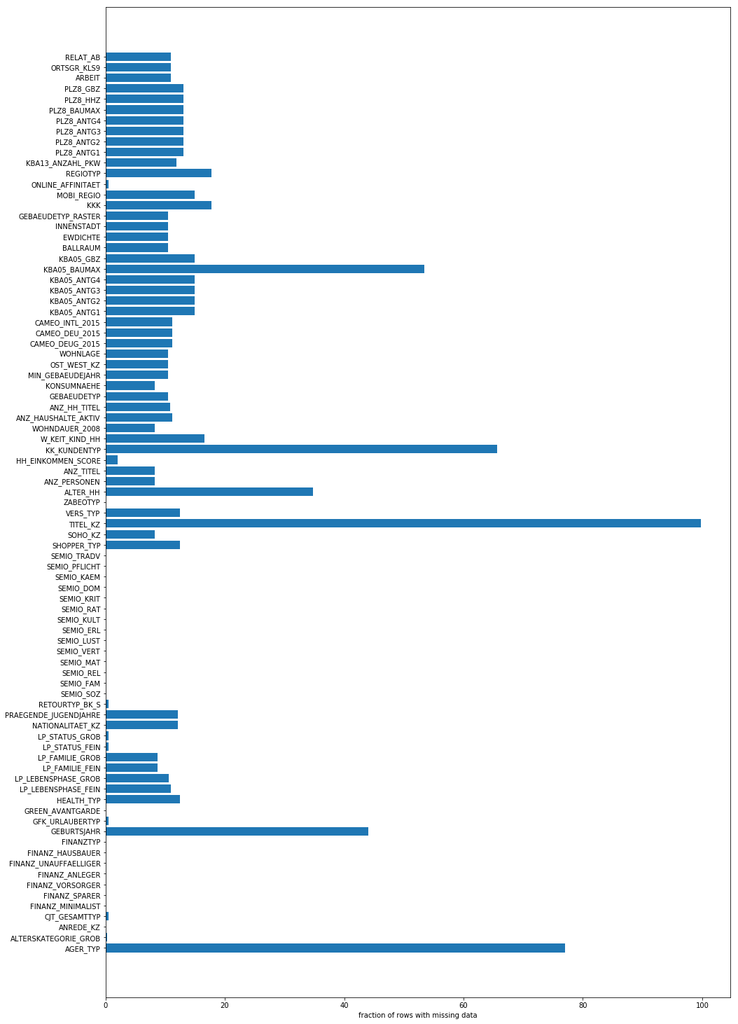

```python
plt.figure(figsize=(16,26))
plt.yticks(np.arange(len(prop_missing)),prop_missing.index,rotation='horizontal')
plt.xlabel('fraction of rows with missing data')
plt.barh(np.arange(len(prop_missing)), prop_missing)
```

```python
# Columns with NaN distribution > 25%
prop_missing_top = pd.Series(prop_missing).where(lambda x : x>25).dropna()
```

```
<Container object of 6 artists>
```

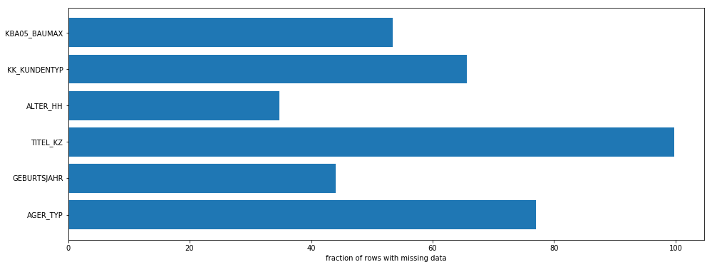

```python
plt.figure(figsize=(16,6))
plt.yticks(np.arange(len(prop_missing_top)),prop_missing_top.index,rotation='horizontal')
plt.xlabel('fraction of rows with missing data')
plt.barh(np.arange(len(prop_missing_top)), prop_missing_top)
```

```python
# Investigate patterns in the amount of missing data in each column.
lookup_il = feat_info.set_index(['attribute'])['information_level'].to_dict()
```

```python
prop_missing_il = pd.concat([prop_missing, pd.DataFrame.from_dict(lookup_il, orient='index')], axis=1)
```

```python
prop_missing_il.columns = ['missing_prob', 'information_level']
```

```python
prop_missing_il.groupby(['information_level']).mean()
```

| information_level | missing_prob |
| --- | --- |
| building | 10.309772 |
| community | 10.922244 |
| household | 20.545040 |
| macrocell_plz8 | 12.923352 |
| microcell_rr3 | 21.377863 |
| microcell_rr4 | 11.147852 |
| person | 7.738866 |
| postcode | 10.518154 |
| region_rr1 | 12.285640 |

```python
azdias.to_csv('Udacity_AZDIAS_Subset_addl.csv', sep=';', encoding='utf-8', index=False)
feat_info.to_csv('AZDIAS_Feature_Summary_addl.csv', sep=';', encoding='utf-8', index=False)
```

```python
# Remove the outlier columns from the dataset. (You'll perform other data
# engineering tasks such as re-encoding and imputation later.)
azdias.drop(columns=['AGER_TYP','GEBURTSJAHR','TITEL_KZ','ALTER_HH','KK_KUNDENTYP','KBA05_BAUMAX'], axis=1, inplace=True)
```

```python
# Load in the general demographics data.
azdias = pd.read_csv('Udacity_AZDIAS_Subset_addl.csv', sep=';')

# Load in the feature summary file.
feat_info = pd.read_csv('AZDIAS_Feature_Summary_addl.csv', sep=';')
```

```python
azdias=reduce_mem_usage(azdias)
print('azdias set shape:', azdias.shape)
```

```
Memory usage of dataframe is 577.96 MB
Memory usage after optimization is: 154.69 MB
Decreased by 73.2%
azdias set shape: (891221, 85)
```

#### Discussion 1.1.2: Assess Missing Data in Each Column

Most columns had missing data. Those with a proportion > 25% are:

76.955435 --> AGER_TYP

44.020282 --> GEBURTSJAHR

99.757636 --> TITEL_KZ

34.813699 --> ALTER_HH

65.596749 --> KK_KUNDENTYP

53.468668 --> KBA05_BAUMAX

Additionally, when missing data proportion is computed by Information Level, the distribution is as under:

10.309772 --> building

10.922244 --> community

20.545040 --> household

12.923352 --> macrocell_plz8

21.377863 --> microcell_rr3

11.147852 --> microcell_rr4

7.738866 --> person

10.518154 --> postcode

12.285640 --> region_rr1

Columns at the "person" level has the least amount of data missing. While columns at the "household" and "microcell_rr3" levels have the most amount (> 20%).

#### Step 1.1.3: Assess Missing Data in Each Row

Now, you'll perform a similar assessment for the rows of the dataset. How much data is missing in each row? As with the columns, you should see some groups of points that have a very different numbers of missing values. Divide the data into two subsets: one for data points that are above some threshold for missing values, and a second subset for points below that threshold.

In order to know what to do with the outlier rows, we should see if the distribution of data values on columns that are not missing data (or are missing very little data) are similar or different between the two groups. Select at least five of these columns and compare the distribution of values.

- You can use seaborn's [`countplot()`](https://seaborn.pydata.org/generated/seaborn.countplot.html) function to create a bar chart of code frequencies and matplotlib's [`subplot()`](https://matplotlib.org/api/_as_gen/matplotlib.pyplot.subplot.html) function to put bar charts for the two subplots side by side.
- To reduce repeated code, you might want to write a function that can perform this comparison, taking as one of its arguments a column to be compared.

Depending on what you observe in your comparison, this will have implications on how you approach your conclusions later in the analysis. If the distributions of non-missing features look similar between the data with many missing values and the data with few or no missing values, then we could argue that simply dropping those points from the analysis won't present a major issue. On the other hand, if the data with many missing values looks very different from the data with few or no missing values, then we should make a note on those data as special. We'll revisit these data later on. **Either way, you should continue your analysis for now using just the subset of the data with few or no missing values.**

```python
# How much data is missing in each row of the dataset?

azdias['missing_data_count'] = azdias.apply(lambda x: sum(x.isnull().values), axis = 1) # For rows
```

```python
total_recs = len(azdias)
for i in range(5,30,2):
    pct = azdias[azdias['missing_data_count'] > i].count(axis=1).count() / total_recs * 100
    print('Missing Data Columns:', i, '% of Records: {0:.2f}'.format(pct))
```

```
Missing Data Columns: 5 % of Records: 32.76
Missing Data Columns: 7 % of Records: 22.76
Missing Data Columns: 9 % of Records: 19.14
Missing Data Columns: 11 % of Records: 16.17
Missing Data Columns: 13 % of Records: 13.50
Missing Data Columns: 15 % of Records: 12.41
Missing Data Columns: 17 % of Records: 11.83
Missing Data Columns: 19 % of Records: 11.14
Missing Data Columns: 21 % of Records: 10.80
Missing Data Columns: 23 % of Records: 10.60
Missing Data Columns: 25 % of Records: 10.53
Missing Data Columns: 27 % of Records: 10.49
Missing Data Columns: 29 % of Records: 10.47
```

```python
# Write code to divide the data into two subsets based on the number of missing
# values in each row.
missing_threshold = 10
azdias_bt = azdias[azdias['missing_data_count'] >= missing_threshold]
azdias_at = azdias[azdias['missing_data_count'] < missing_threshold]
print('Records - Total          :', len(azdias))
print('Records - Below Threshold:', len(azdias_bt))
print('Records - Above Threshold:', len(azdias_at))
```

```
Records - Total          : 891221
Records - Below Threshold: 170621
Records - Above Threshold: 720600
```

```python
# Compare the distribution of values for at least five columns where there are
# no or few missing values, between the two subsets.

def compare_distribution(data_at, data_bt, feature):
    f, (ax1, ax2) = plt.subplots(2)
    #f, axes = plt.subplots(1, 2)
    sns.countplot(data=data_bt, x=data_bt[feature], ax=ax1)
    sns.countplot(data=data_at, x=data_at[feature], ax=ax2)
    plt.show()
```

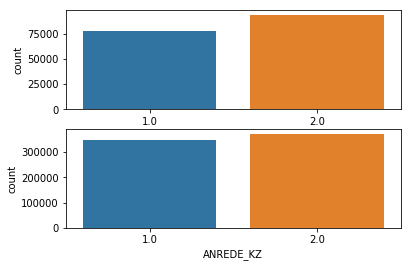

```python
compare_distribution(azdias_at, azdias_bt, 'ANREDE_KZ')
```

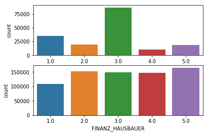

```python
compare_distribution(azdias_at, azdias_bt, 'FINANZ_HAUSBAUER')
```

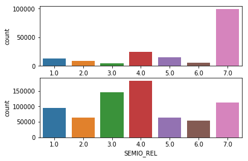

```python
compare_distribution(azdias_at, azdias_bt, 'SEMIO_REL')
```

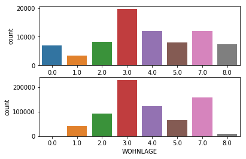

```python
compare_distribution(azdias_at, azdias_bt, 'WOHNLAGE')
```

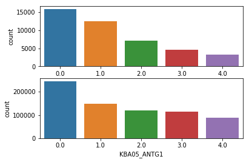

```python
compare_distribution(azdias_at, azdias_bt, 'KBA05_ANTG1')
```

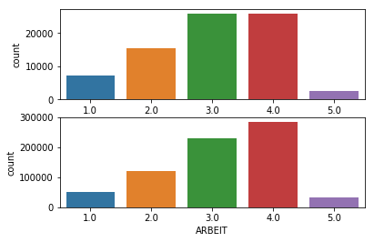

```python
compare_distribution(azdias_at, azdias_bt, 'ARBEIT')
```

```python
azdias_at.to_csv('Udacity_AZDIAS_Subset_11.csv', sep=';', encoding='utf-8', index=False)
feat_info.to_csv('AZDIAS_Feature_Summary_11.csv', sep=';', encoding='utf-8', index=False)
```

```python
# Load in the general demographics data.
azdias = pd.read_csv('Udacity_AZDIAS_Subset_11.csv', sep=';')

# Load in the feature summary file.
feat_info = pd.read_csv('AZDIAS_Feature_Summary_11.csv', sep=';')
```

#### Discussion 1.1.3: Assess Missing Data in Each Row

As there isno significant increase in the % of records with missing data columns, the threshold was taken as 10 columns i.e. records with 10 or more missing values were classified as below threshold and those with < 10 missing values were classified as above threshold.

### Step 1.2: Select and Re-Encode Features

Checking for missing data isn't the only way in which you can prepare a dataset for analysis. Since the unsupervised learning techniques to be used will only work on data that is encoded numerically, you need to make a few encoding changes or additional assumptions to be able to make progress. In addition, while almost all of the values in the dataset are encoded using numbers, not all of them represent numeric values. Check the third column of the feature summary (`feat_info`) for a summary of types of measurement.

- For numeric and interval data, these features can be kept without changes.
- Most of the variables in the dataset are ordinal in nature. While ordinal values may technically be non-linear in spacing, make the simplifying assumption that the ordinal variables can be treated as being interval in nature (that is, kept without any changes).
- Special handling may be necessary for the remaining two variable types: categorical, and 'mixed'.

In the first two parts of this sub-step, you will perform an investigation of the categorical and mixed-type features and make a decision on each of them, whether you will keep, drop, or re-encode each. Then, in the last part, you will create a new data frame with only the selected and engineered columns.

Data wrangling is often the trickiest part of the data analysis process, and there's a lot of it to be done here. But stick with it: once you're done with this step, you'll be ready to get to the machine learning parts of the project!

```python
# How many features are there of each data type?
feat_info.groupby(['type']).size()
```

```
type
categorical    21
interval        1
mixed           7
numeric         7
ordinal        49
dtype: int64
```

#### Step 1.2.1: Re-Encode Categorical Features

For categorical data, you would ordinarily need to encode the levels as dummy variables. Depending on the number of categories, perform one of the following:

- For binary (two-level) categoricals that take numeric values, you can keep them without needing to do anything.
- There is one binary variable that takes on non-numeric values. For this one, you need to re-encode the values as numbers or create a dummy variable.
- For multi-level categoricals (three or more values), you can choose to encode the values using multiple dummy variables (e.g. via [OneHotEncoder](http://scikit-learn.org/stable/modules/generated/sklearn.preprocessing.OneHotEncoder.html)), or (to keep things straightforward) just drop them from the analysis. As always, document your choices in the Discussion section.

```python
# Assess categorical variables: which are binary, which are multi-level, and
# which one needs to be re-encoded?
att_categorical = feat_info[feat_info['type'] == 'categorical']['attribute']
```

```python
# binary categoricals
for att in att_categorical:
    if att not in ['AGER_TYP','GEBURTSJAHR','TITEL_KZ','ALTER_HH','KK_KUNDENTYP','KBA05_BAUMAX']:
        if len(azdias[att].unique()) <= 3:
            if len(att) > 14:
                print(att, '\tUnique Values:', azdias[att].unique())
            else:
                print(att, '\t\tUnique Values:', azdias[att].unique())
            if azdias[att].isnull().values.any():
                print(azdias.groupby([att]).size())
                print('nan ', len(azdias) - sum(azdias.groupby([att]).size()))
            print('\n')
```

```
ANREDE_KZ 		Unique Values: [ 2.  1.]


GREEN_AVANTGARDE 	Unique Values: [ 0.  1.]


SOHO_KZ 		Unique Values: [ 1.  0.]


VERS_TYP 		Unique Values: [  2.   1.  nan]
VERS_TYP
1.0    332708
2.0    372945
dtype: int64
nan  14947


OST_WEST_KZ 		Unique Values: ['W' 'O']
```

```python
# multi-level categoricals
for att in att_categorical:
    if att not in ['AGER_TYP','GEBURTSJAHR','TITEL_KZ','ALTER_HH','KK_KUNDENTYP','KBA05_BAUMAX']:
        if len(azdias[att].unique()) > 3:
            if len(att) > 14:
                print(att, '\tUnique Values:', azdias[att].unique())
            else:
                print(att, '\t\tUnique Values:', azdias[att].unique())
            print('\n')
```

```
CJT_GESAMTTYP 		Unique Values: [ 5.  3.  2.  4.  1.  6.]


FINANZTYP 		Unique Values: [ 1.  6.  5.  2.  4.  3.]


GFK_URLAUBERTYP 	Unique Values: [ 10.   1.   5.  12.   9.   3.   8.  11.   4.   7.   2.   6.]


LP_FAMILIE_FEIN 	Unique Values: [  5.   1.  nan  10.   2.   7.  11.   8.   4.   6.   9.   3.]


LP_FAMILIE_GROB 	Unique Values: [  3.   1.  nan   5.   2.   4.]


LP_STATUS_FEIN 		Unique Values: [  2.   3.   9.   4.   1.  10.   8.   5.   6.   7.]


LP_STATUS_GROB 		Unique Values: [ 1.  2.  4.  5.  3.]


NATIONALITAET_KZ 	Unique Values: [  1.   3.   2.  nan]


SHOPPER_TYP 		Unique Values: [  3.   2.   1.   0.  nan]


ZABEOTYP 		Unique Values: [ 5.  3.  4.  1.  6.  2.]


GEBAEUDETYP 		Unique Values: [ 8.  1.  3.  2.  6.  4.  5.]


CAMEO_DEUG_2015 	Unique Values: [  8.   4.   2.   6.   1.   9.   7.   5.   3.  nan]


CAMEO_DEU_2015 		Unique Values: ['8A' '4C' '2A' '6B' '8C' '4A' '2D' '1A' '1E' '9D' '7A' '5D' '9E' '5C' '9B'
 '1B' '8B' '3D' nan '4E' '4B' '3C' '5A' '7B' '9A' '6D' '6E' '2C' '7C' '9C'
 '7D' '5E' '1D' '8D' '6C' '6A' '5B' '4D' '3A' '2B' '7E' '3B' '6F' '5F' '1C']
```

```python
# Re-encode categorical variable(s) to be kept in the analysis.

# binary categoricals | Encode OST_WEST_KZ to numerical values
azdias['OST_WEST_KZ'] = azdias['OST_WEST_KZ'].apply(lambda x: 1 if x=='W' else 0)
```

```python
# binary categoricals | Impute NaN values in VERS_TYP to most frequently occuring value
azdias['VERS_TYP'] = azdias['VERS_TYP'].apply(lambda x: 2.0 if x not in (1.0, 2.0) else x)
```

```python
# multi-level categoricals | drop all
for att in att_categorical:
    if att not in ['AGER_TYP','GEBURTSJAHR','TITEL_KZ','ALTER_HH','KK_KUNDENTYP','KBA05_BAUMAX']:
        if len(azdias[att].unique()) > 3:
            azdias.drop(columns=[att], axis=1, inplace=True)
```

#### Discussion 1.2.1: Re-Encode Categorical Features

Binary Categoricals: There are 5 of this kind in all and all of them were retained. However, feature OST_WEST_KZ had non-numeric data and these were re-encoded to numeric. Also, feature VERS_TYP had NaN values and these were replaced with the most frequently occuring non-NaN value.

GFK_URLAUBERTYP

LP_FAMILIE_FEIN

LP_FAMILIE_GROB

LP_STATUS_FEIN

LP_STATUS_GROB

SHOPPER_TYP

ZABEOTYP

GEBAEUDETYP

CAMEO_DEUG_2015

CAMEO_DEU_2015

#### Step 1.2.2: Engineer Mixed-Type Features

There are a handful of features that are marked as "mixed" in the feature summary that require special treatment in order to be included in the analysis. There are two in particular that deserve attention; the handling of the rest are up to your own choices:

- "PRAEGENDE_JUGENDJAHRE" combines information on three dimensions: generation by decade, movement (mainstream vs. avantgarde), and nation (east vs. west). While there aren't enough levels to disentangle east from west, you should create two new variables to capture the other two dimensions: an interval-type variable for decade, and a binary variable for movement.
- "CAMEO_INTL_2015" combines information on two axes: wealth and life stage. Break up the two-digit codes by their 'tens'-place and 'ones'-place digits into two new ordinal variables (which, for the purposes of this project, is equivalent to just treating them as their raw numeric values).
- If you decide to keep or engineer new features around the other mixed-type features, make sure you note your steps in the Discussion section.

Be sure to check `Data_Dictionary.md` for the details needed to finish these tasks.

```python
# Investigate "PRAEGENDE_JUGENDJAHRE" and engineer two new variables.

azdias.groupby(['PRAEGENDE_JUGENDJAHRE']).size()
```

```
PRAEGENDE_JUGENDJAHRE
1.0      19190
2.0       7177
3.0      50736
4.0      19798
5.0      79723
6.0      24558
7.0       3815
8.0     129916
9.0      31732
10.0     78602
11.0     32385
12.0     22856
13.0      5137
14.0    169225
15.0     38590
dtype: int64
```

```python
# binary categoricals | Impute NaN values in PRAEGENDE_JUGENDJAHRE to most frequently occuring value
azdias['PRAEGENDE_JUGENDJAHRE'] = azdias['PRAEGENDE_JUGENDJAHRE'].apply(lambda x:14.0 if pd.isnull(x) else x)
```

```python
azdias.groupby(['PRAEGENDE_JUGENDJAHRE']).size()
```

```
PRAEGENDE_JUGENDJAHRE
1.0      19190
2.0       7177
3.0      50736
4.0      19798
5.0      79723
6.0      24558
7.0       3815
8.0     129916
9.0      31732
10.0     78602
11.0     32385
12.0     22856
13.0      5137
14.0    176385
15.0     38590
dtype: int64
```

```python
azdias['PRAEGENDE_JUGENDJAHRE_decade'] = azdias['PRAEGENDE_JUGENDJAHRE'].apply(lambda x:1 if x < 3.0 else 2 if (x > 2 and x < 5) else 3 if (x > 4 and x < 8) else 4 if (x > 7 and x < 10) else 5 if (x > 9 and x < 14) else 6)
```

```python
azdias['PRAEGENDE_JUGENDJAHRE_movement'] = azdias['PRAEGENDE_JUGENDJAHRE'].apply(lambda x:1.0 if x in (1.0, 3.0, 5.0, 8.0, 10.0, 12.0, 14.0) else 2.0)
```

```python
# Investigate "CAMEO_INTL_2015" and engineer two new variables.

azdias.groupby(['CAMEO_INTL_2015']).size()
```

```
CAMEO_INTL_2015
12.0     11635
13.0     23746
14.0     57163
15.0     15853
22.0     29365
23.0     19544
24.0     82709
25.0     36339
31.0     15600
32.0      9413
33.0      8766
34.0     16900
35.0      9544
41.0     84499
43.0     52073
44.0     13581
45.0     24441
51.0    123468
52.0     18932
54.0     42271
55.0     21822
dtype: int64
```

```python
sum(azdias['CAMEO_INTL_2015'].isnull())
```

```
2936
```

```python
# binary categoricals | Impute NaN values in CAMEO_INTL_2015 to most frequently occuring value
azdias['CAMEO_INTL_2015'] = azdias['CAMEO_INTL_2015'].apply(lambda x:51.0 if pd.isnull(x) else x)
```

```python
azdias.groupby(['CAMEO_INTL_2015']).size()
```

```
CAMEO_INTL_2015
12.0     11635
13.0     23746
14.0     57163
15.0     15853
22.0     29365
23.0     19544
24.0     82709
25.0     36339
31.0     15600
32.0      9413
33.0      8766
34.0     16900
35.0      9544
41.0     84499
43.0     52073
44.0     13581
45.0     24441
51.0    126404
52.0     18932
54.0     42271
55.0     21822
dtype: int64
```

```python
azdias['CAMEO_INTL_2015_wealth'] = azdias['CAMEO_INTL_2015'].apply(lambda x:int(x/10))
```

```python
azdias['CAMEO_INTL_2015_lifestage'] = azdias['CAMEO_INTL_2015'].apply(lambda x:x%10)
```

```python
azdias.drop(columns=['PRAEGENDE_JUGENDJAHRE','CAMEO_INTL_2015'], axis=1, inplace=True)
```

```python
azdias.drop(columns=['WOHNLAGE','PLZ8_BAUMAX'], axis=1, inplace=True)
```

#### Discussion 1.2.2: Engineer Mixed-Type Features

Only the two mixed-type features mentioned above [PRAEGENDE_JUGENDJAHRE & CAMEO_INTL_2015] have been engineered as per instructions.

Additionally, features WOHNLAGE and PLZ8_BAUMAX have been dropped as the scale is ordinal for some values but not for the rest. No others have been taken up.

#### Step 1.2.3: Complete Feature Selection

In order to finish this step up, you need to make sure that your data frame now only has the columns that you want to keep. To summarize, the dataframe should consist of the following:

- All numeric, interval, and ordinal type columns from the original dataset.
- Binary categorical features (all numerically-encoded).
- Engineered features from other multi-level categorical features and mixed features.

Make sure that for any new columns that you have engineered, that you've excluded the original columns from the final dataset. Otherwise, their values will interfere with the analysis later on the project. For example, you should not keep "PRAEGENDE_JUGENDJAHRE", since its values won't be useful for the algorithm: only the values derived from it in the engineered features you created should be retained. As a reminder, your data should only be from **the subset with few or no missing values**.

```python
# If there are other re-engineering tasks you need to perform, make sure you
# take care of them here. (Dealing with missing data will come in step 2.1.)
azdias.shape
```

```
(720600, 73)
```

```python
azdias.describe()
```

|  | AGER_TYP | ALTERSKATEGORIE_GROB | ANREDE_KZ | FINANZ_MINIMALIST | FINANZ_SPARER | FINANZ_VORSORGER | FINANZ_ANLEGER | FINANZ_UNAUFFAELLIGER | FINANZ_HAUSBAUER | GEBURTSJAHR | GREEN_AVANTGARDE | HEALTH_TYP | LP_LEBENSPHASE_FEIN | LP_LEBENSPHASE_GROB | RETOURTYP_BK_S | SEMIO_SOZ | SEMIO_FAM | SEMIO_REL | SEMIO_MAT | SEMIO_VERT | SEMIO_LUST | SEMIO_ERL | SEMIO_KULT | SEMIO_RAT | SEMIO_KRIT | SEMIO_DOM | SEMIO_KAEM | SEMIO_PFLICHT | SEMIO_TRADV | … |
| --- | --- | --- | --- | --- | --- | --- | --- | --- | --- | --- | --- | --- | --- | --- | --- | --- | --- | --- | --- | --- | --- | --- | --- | --- | --- | --- | --- | --- | --- | --- |
| count | 191298.000000 | 719032.000000 | 720600.000000 | 720600.000000 | 720600.000000 | 720600.000000 | 720600.000000 | 720600.000000 | 720600.000000 | 453866.000000 | 720600.000000 | 705653.000000 | 705829.000000 | 706001.000000 | 720600.000000 | 720600.000000 | 720600.000000 | 720600.000000 | 720600.000000 | 720600.000000 | 720600.000000 | 720600.000000 | 720600.000000 | 720600.000000 | 720600.00000 | 720600.000000 | 720600.000000 | 720600.000000 | 720600.000000 | … |
| mean | 1.722632 | 2.793528 | 1.516382 | 3.075645 | 2.665569 | 3.459242 | 2.789944 | 2.568464 | 3.149557 | 1966.855308 | 0.226467 | 2.211285 | 16.230665 | 4.933112 | 3.412274 | 4.198174 | 4.091056 | 3.930537 | 3.839083 | 4.283335 | 4.340613 | 4.614767 | 4.155590 | 3.863356 | 4.50899 | 4.576053 | 4.282431 | 4.143546 | 3.746654 | … |
| std | 0.675941 | 1.029970 | 0.499732 | 1.362104 | 1.472551 | 1.387685 | 1.455939 | 1.376250 | 1.381422 | 17.831628 | 0.418545 | 0.755371 | 12.283844 | 3.765295 | 1.456418 | 1.948781 | 1.910116 | 1.882503 | 1.930256 | 1.917063 | 2.097229 | 1.822538 | 1.967257 | 1.663662 | 1.74243 | 1.836469 | 1.883606 | 1.882598 | 1.772362 | … |
| min | 1.000000 | 1.000000 | 1.000000 | 1.000000 | 1.000000 | 1.000000 | 1.000000 | 1.000000 | 1.000000 | 1900.000000 | 0.000000 | 1.000000 | 1.000000 | 1.000000 | 1.000000 | 1.000000 | 1.000000 | 1.000000 | 1.000000 | 1.000000 | 1.000000 | 1.000000 | 1.000000 | 1.000000 | 1.00000 | 1.000000 | 1.000000 | 1.000000 | 1.000000 | … |
| 25% | 1.000000 | 2.000000 | 1.000000 | 2.000000 | 1.000000 | 2.000000 | 1.000000 | 1.000000 | 2.000000 | 1954.000000 | 0.000000 | 2.000000 | 5.000000 | 2.000000 | 2.000000 | 2.000000 | 2.000000 | 3.000000 | 2.000000 | 2.000000 | 2.000000 | 3.000000 | 3.000000 | 3.000000 | 3.00000 | 3.000000 | 3.000000 | 3.000000 | 2.000000 | … |
| 50% | 2.000000 | 3.000000 | 2.000000 | 3.000000 | 2.000000 | 4.000000 | 3.000000 | 2.000000 | 3.000000 | 1967.000000 | 0.000000 | 2.000000 | 13.000000 | 3.000000 | 4.000000 | 4.000000 | 4.000000 | 4.000000 | 4.000000 | 5.000000 | 5.000000 | 4.000000 | 4.000000 | 4.000000 | 5.00000 | 5.000000 | 4.000000 | 4.000000 | 4.000000 | … |
| 75% | 2.000000 | 4.000000 | 2.000000 | 4.000000 | 4.000000 | 5.000000 | 4.000000 | 4.000000 | 4.000000 | 1981.000000 | 0.000000 | 3.000000 | 29.000000 | 8.000000 | 5.000000 | 6.000000 | 6.000000 | 5.000000 | 5.000000 | 6.000000 | 6.000000 | 6.000000 | 6.000000 | 5.000000 | 6.00000 | 6.000000 | 6.000000 | 6.000000 | 5.000000 | … |
| max | 3.000000 | 4.000000 | 2.000000 | 5.000000 | 5.000000 | 5.000000 | 5.000000 | 5.000000 | 5.000000 | 2017.000000 | 1.000000 | 3.000000 | 40.000000 | 12.000000 | 5.000000 | 7.000000 | 7.000000 | 7.000000 | 7.000000 | 7.000000 | 7.000000 | 7.000000 | 7.000000 | 7.000000 | 7.00000 | 7.000000 | 7.000000 | 7.000000 | 7.000000 | … |

```python
# Do whatever you need to in order to ensure that the dataframe only contains
# the columns that should be passed to the algorithm functions.
azdias_counts_mou = azdias['missing_data_count']
azdias = azdias.drop('missing_data_count', axis = 1)
```

```python
azdias.to_csv('Udacity_AZDIAS_Subset_12.csv', sep=';', encoding='utf-8', index=False)
azdias_counts_mou.to_csv('Udacity_AZDIAS_counts_mou_12.csv', sep=';', encoding='utf-8', index=False)
feat_info.to_csv('AZDIAS_Feature_Summary_12.csv', sep=';', encoding='utf-8', index=False)
```

### Step 1.3: Create a Cleaning Function

Even though you've finished cleaning up the general population demographics data, it's important to look ahead to the future and realize that you'll need to perform the same cleaning steps on the customer demographics data. In this substep, complete the function below to execute the main feature selection, encoding, and re-engineering steps you performed above. Then, when it comes to looking at the customer data in Step 3, you can just run this function on that DataFrame to get the trimmed dataset in a single step.

```python
def clean_data(df):
    """
    Perform feature trimming, re-encoding, and engineering for demographics
    data

    INPUT: Demographics DataFrame
    OUTPUT: Trimmed and cleaned demographics DataFrame
    """

    df = reduce_mem_usage(df)
    df = convert_int_to_float(df)

    # Load in the feature summary file and create a dict of missing/unknown values.
    feat_info = pd.read_csv('AZDIAS_Feature_Summary_12.csv', sep=';')
    for feat_idx, feat_row in feat_info.iterrows():
        feat_info.iat[feat_idx,5] = list(feat_row['missing_or_unknown'][1:-1].split(","))
        if 'float' in str(feat_row['attribute_dtype']):
            feat_info.iat[feat_idx,5] = [float(integral) if len(str(integral)) > 0 else np.nan for integral in feat_info.iat[feat_idx,5]]
    lookup_mou = feat_info.set_index(['attribute'])['missing_or_unknown_list'].to_dict()

    print('Shape Initial: ', df.shape)

    # Put in code here to execute all main cleaning steps:
    # convert missing value codes into NaNs, ...

    # Identify missing or unknown data values and convert them to NaNs.
    print('STEP #1: Identify missing or unknown data values and convert them to NaNs')
    t1 = time.time()
    for data_idx, data_row in df.iterrows():
        for col in df.columns:
            col_idx = df.columns.get_loc(col)
            if df.at[data_idx, col] in lookup_mou[col]:
                df.at[data_idx, col] = np.nan
        if data_idx % 10000 == 0:
            print('Current Index:',data_idx, 'Elapsed Time:', time.time() - t1)

    # remove selected columns and rows, ...
    # Remove the outlier columns from the dataset. (You'll perform other data
    # engineering tasks such as re-encoding and imputation later.)
    print('STEP #2: Remove columns with missing values')
    df.drop(columns=['AGER_TYP','GEBURTSJAHR','TITEL_KZ','ALTER_HH','KK_KUNDENTYP','KBA05_BAUMAX'], axis=1, inplace=True)

    # Write code to divide the data into two subsets based on the number of missing
    # values in each row.
    print('STEP #3: Remove rows with missing values')

    # How much data is missing in each row of the dataset?
    df['missing_data_count'] = df.apply(lambda x: sum(x.isnull().values), axis = 1) # For rows
    total_recs = len(df)
    for i in range(5,30,2):
        pct = df[df['missing_data_count'] > i].count(axis=1).count() / total_recs * 100
        print('Missing Data Columns:', i, '% of Records: {0:.2f}'.format(pct))

    missing_threshold = 10
    df_bt = df[df['missing_data_count'] >= missing_threshold]
    df_at = df[df['missing_data_count'] < missing_threshold]
    print('Records - Total          :', len(df))
    print('Records - Below Threshold:', len(df_bt))
    print('Records - Above Threshold:', len(df_at))

    # select, re-encode, and engineer column values.
    # Re-encode categorical variable(s) to be kept in the analysis.

    print('STEP #4: Re-encode categorical variables')
    # Assess categorical variables: which are binary, which are multi-level, and
    # which one needs to be re-encoded?
    att_categorical = feat_info[feat_info['type'] == 'categorical']['attribute']

    # binary categoricals | Encode OST_WEST_KZ to numerical values
    df_at['OST_WEST_KZ'] = df_at['OST_WEST_KZ'].apply(lambda x: 1 if x=='W' else 0)

    # binary categoricals | Impute NaN values in VERS_TYP to most frequently occuring value
    df_at['VERS_TYP'] = df_at['VERS_TYP'].apply(lambda x: 2.0 if x not in (1.0, 2.0) else x)

    # multi-level categoricals | drop all
    for att in att_categorical:
        if att not in ['AGER_TYP','GEBURTSJAHR','TITEL_KZ','ALTER_HH','KK_KUNDENTYP','KBA05_BAUMAX']:
            if len(df_at[att].unique()) > 3:
                df_at.drop(columns=[att], axis=1, inplace=True)

    # binary categoricals | Impute NaN values in PRAEGENDE_JUGENDJAHRE to most frequently occuring value
    df_at['PRAEGENDE_JUGENDJAHRE'] = df_at['PRAEGENDE_JUGENDJAHRE'].apply(lambda x:14.0 if pd.isnull(x) else x)
    df_at['PRAEGENDE_JUGENDJAHRE_decade'] = df_at['PRAEGENDE_JUGENDJAHRE'].apply(lambda x:1 if x < 3.0 else 2 if (x > 2 and x < 5) else 3 if (x > 4 and x < 8) else 4 if (x > 7 and x < 10) else 5 if (x > 9 and x < 14) else 6)
    df_at['PRAEGENDE_JUGENDJAHRE_movement'] = df_at['PRAEGENDE_JUGENDJAHRE'].apply(lambda x:1.0 if x in (1.0, 3.0, 5.0, 8.0, 10.0, 12.0, 14.0) else 2.0)

    # binary categoricals | Impute NaN values in CAMEO_INTL_2015 to most frequently occuring value
    df_at['CAMEO_INTL_2015'] = df_at['CAMEO_INTL_2015'].apply(lambda x:51.0 if pd.isnull(x) else x)
    df_at['CAMEO_INTL_2015_wealth'] = df_at['CAMEO_INTL_2015'].apply(lambda x: int(float(x)/10) if str.isdigit(str(x)) else np.nan)
    df_at['CAMEO_INTL_2015_lifestage'] = df_at['CAMEO_INTL_2015'].apply(lambda x:int(x)%10 if str.isdigit(str(x)) else np.nan)

    df_at.drop(columns=['PRAEGENDE_JUGENDJAHRE','CAMEO_INTL_2015','missing_data_count'], axis=1, inplace=True)
    df_at.drop(columns=['WOHNLAGE','PLZ8_BAUMAX'], axis=1, inplace=True)

    print('Shape Final: ', df_at.shape)

    # Return the cleaned dataframe.
    return df_at
```

```python
# Test Cleaning Function

# Load in the general demographics data.
azdias = pd.read_csv('Udacity_AZDIAS_Subset.csv', sep=';')

# Load in the feature summary file.
feat_info = pd.read_csv('AZDIAS_Feature_Summary.csv', sep=';')
```

```python
azdias_cleaned = clean_data(azdias)
```

[output not shown]

[output cut: 59 more lines]

```
Missing Data Columns: 9 % of Records: 13.07
Missing Data Columns: 11 % of Records: 12.34
Missing Data Columns: 13 % of Records: 11.88
Missing Data Columns: 15 % of Records: 11.10
Missing Data Columns: 17 % of Records: 10.74
Missing Data Columns: 19 % of Records: 10.56
Missing Data Columns: 21 % of Records: 10.51
Missing Data Columns: 23 % of Records: 10.48
Missing Data Columns: 25 % of Records: 10.46
Missing Data Columns: 27 % of Records: 10.45
Missing Data Columns: 29 % of Records: 10.45
Records - Total          : 891221
Records - Below Threshold: 116478
Records - Above Threshold: 774743
STEP #4: Re-encode categorical variables
```

[output not shown]

```
Shape Final:  (774743, 66)
```

```python
azdias_cleaned.to_csv('Udacity_AZDIAS_Subset_13.csv', sep=';', encoding='utf-8', index=False)
feat_info.to_csv('AZDIAS_Feature_Summary_13.csv', sep=';', encoding='utf-8', index=False)
```

```python
# Load in the general demographics data.
azdias_cleaned = pd.read_csv('Udacity_AZDIAS_Subset_13.csv', sep=';')

# Load in the feature summary file.
feat_info = pd.read_csv('AZDIAS_Feature_Summary_13.csv', sep=';')
```

## Step 2: Feature Transformation

### Step 2.1: Apply Feature Scaling

Before we apply dimensionality reduction techniques to the data, we need to perform feature scaling so that the principal component vectors are not influenced by the natural differences in scale for features. Starting from this part of the project, you'll want to keep an eye on the [API reference page for sklearn](http://scikit-learn.org/stable/modules/classes.html) to help you navigate to all of the classes and functions that you'll need. In this substep, you'll need to check the following:

- sklearn requires that data not have missing values in order for its estimators to work properly. So, before applying the scaler to your data, make sure that you've cleaned the DataFrame of the remaining missing values. This can be as simple as just removing all data points with missing data, or applying an [Imputer](http://scikit-learn.org/stable/modules/generated/sklearn.preprocessing.Imputer.html) to replace all missing values. You might also try a more complicated procedure where you temporarily remove missing values in order to compute the scaling parameters before re-introducing those missing values and applying imputation. Think about how much missing data you have and what possible effects each approach might have on your analysis, and justify your decision in the discussion section below.
- For the actual scaling function, a [StandardScaler](http://scikit-learn.org/stable/modules/generated/sklearn.preprocessing.StandardScaler.html) instance is suggested, scaling each feature to mean 0 and standard deviation 1.
- For these classes, you can make use of the `.fit_transform()` method to both fit a procedure to the data as well as apply the transformation to the data at the same time. Don't forget to keep the fit sklearn objects handy, since you'll be applying them to the customer demographics data towards the end of the project.

```python
# If you've not yet cleaned the dataset of all NaN values, then investigate and
# do that now.
prop_missing = azdias_cleaned.isna().sum()/len(azdias_cleaned) * 100
```

```python
print('Columns with missing values [Before Impute]:', prop_missing[prop_missing > 0].count())
```

```
Columns with missing values [Before Impute]: 32
```

```python
imputer = Imputer(missing_values='NaN',strategy='mean',axis=0)
azdias_imputed = imputer.fit_transform(azdias_cleaned)
```

```python
azdias_imputed = pd.DataFrame(azdias_imputed)
azdias_imputed.columns = azdias_cleaned.columns
```

```python
prop_missing_imputed = azdias_imputed.isna().sum()/len(azdias_imputed) * 100
```

```python
print('Columns with missing values [After Impute]:', prop_missing_imputed[prop_missing_imputed > 0].count())
```

```
Columns with missing values [After Impute]: 0
```

```python
azdias_imputed.describe()
```

|  | ALTERSKATEGORIE_GROB | ANREDE_KZ | FINANZ_MINIMALIST | FINANZ_SPARER | FINANZ_VORSORGER | FINANZ_ANLEGER | FINANZ_UNAUFFAELLIGER | FINANZ_HAUSBAUER | GREEN_AVANTGARDE | HEALTH_TYP | LP_LEBENSPHASE_FEIN | LP_LEBENSPHASE_GROB | RETOURTYP_BK_S | SEMIO_SOZ | SEMIO_FAM | SEMIO_REL | SEMIO_MAT | SEMIO_VERT | SEMIO_LUST | SEMIO_ERL | SEMIO_KULT | SEMIO_RAT | SEMIO_KRIT | SEMIO_DOM | SEMIO_KAEM | SEMIO_PFLICHT | SEMIO_TRADV | SOHO_KZ | VERS_TYP | … |
| --- | --- | --- | --- | --- | --- | --- | --- | --- | --- | --- | --- | --- | --- | --- | --- | --- | --- | --- | --- | --- | --- | --- | --- | --- | --- | --- | --- | --- | --- | --- |
| count | 774743.000000 | 774743.000000 | 774743.000000 | 774743.000000 | 774743.000000 | 774743.000000 | 774743.000000 | 774743.000000 | 774743.000000 | 774743.000000 | 774743.000000 | 774743.000000 | 774743.000000 | 774743.000000 | 774743.000000 | 774743.000000 | 774743.000000 | 774743.000000 | 774743.000000 | 774743.000000 | 774743.000000 | 774743.000000 | 774743.000000 | 774743.000000 | 774743.000000 | 774743.000000 | 774743.00000 | 774743.000000 | 774743.000000 | … |
| mean | 2.796903 | 1.521221 | 3.050652 | 2.710942 | 3.438778 | 2.837575 | 2.633012 | 3.144132 | 0.220033 | 2.203911 | 16.286893 | 4.943139 | 3.441522 | 4.157168 | 4.108935 | 3.988119 | 3.870150 | 4.265926 | 4.351997 | 4.624921 | 4.141369 | 3.886743 | 4.536359 | 4.563744 | 4.295171 | 4.183565 | 3.72559 | 0.008382 | 1.542962 | … |
| std | 1.018072 | 0.499550 | 1.377400 | 1.486386 | 1.377239 | 1.472501 | 1.393403 | 1.398325 | 0.414269 | 0.738625 | 11.921997 | 3.657165 | 1.456568 | 1.942848 | 1.908980 | 1.909259 | 1.914241 | 1.937924 | 2.101237 | 1.827604 | 1.958183 | 1.654951 | 1.749391 | 1.824331 | 1.870464 | 1.870657 | 1.76409 | 0.091170 | 0.498151 | … |
| min | 1.000000 | 1.000000 | 1.000000 | 1.000000 | 1.000000 | 1.000000 | 1.000000 | 1.000000 | 0.000000 | 1.000000 | 1.000000 | 1.000000 | 1.000000 | 1.000000 | 1.000000 | 1.000000 | 1.000000 | 1.000000 | 1.000000 | 1.000000 | 1.000000 | 1.000000 | 1.000000 | 1.000000 | 1.000000 | 1.000000 | 1.00000 | 0.000000 | 1.000000 | … |
| 25% | 2.000000 | 1.000000 | 2.000000 | 1.000000 | 2.000000 | 1.000000 | 1.000000 | 2.000000 | 0.000000 | 2.000000 | 6.000000 | 2.000000 | 2.000000 | 2.000000 | 2.000000 | 3.000000 | 2.000000 | 2.000000 | 2.000000 | 3.000000 | 3.000000 | 3.000000 | 3.000000 | 3.000000 | 3.000000 | 3.000000 | 2.00000 | 0.000000 | 1.000000 | … |
| 50% | 3.000000 | 2.000000 | 3.000000 | 3.000000 | 4.000000 | 3.000000 | 2.000000 | 3.000000 | 0.000000 | 2.000000 | 14.000000 | 4.000000 | 4.000000 | 4.000000 | 4.000000 | 4.000000 | 4.000000 | 5.000000 | 5.000000 | 4.000000 | 4.000000 | 4.000000 | 5.000000 | 5.000000 | 4.000000 | 4.000000 | 4.00000 | 0.000000 | 2.000000 | … |
| 75% | 4.000000 | 2.000000 | 4.000000 | 4.000000 | 5.000000 | 4.000000 | 4.000000 | 4.000000 | 0.000000 | 3.000000 | 27.000000 | 8.000000 | 5.000000 | 6.000000 | 6.000000 | 5.000000 | 5.000000 | 6.000000 | 6.000000 | 6.000000 | 6.000000 | 5.000000 | 6.000000 | 6.000000 | 6.000000 | 6.000000 | 5.00000 | 0.000000 | 2.000000 | … |
| max | 4.000000 | 2.000000 | 5.000000 | 5.000000 | 5.000000 | 5.000000 | 5.000000 | 5.000000 | 1.000000 | 3.000000 | 40.000000 | 12.000000 | 5.000000 | 7.000000 | 7.000000 | 7.000000 | 7.000000 | 7.000000 | 7.000000 | 7.000000 | 7.000000 | 7.000000 | 7.000000 | 7.000000 | 7.000000 | 7.000000 | 7.00000 | 1.000000 | 2.000000 | … |

```python
# Apply feature scaling to the general population demographics data.
ss = StandardScaler()
azdias_scaled = ss.fit_transform(azdias_imputed)
```

```python
azdias_scaled = pd.DataFrame(azdias_scaled)
azdias_scaled.columns = azdias_imputed.columns
```

```python
azdias_scaled.describe()
```

|  | ALTERSKATEGORIE_GROB | ANREDE_KZ | FINANZ_MINIMALIST | FINANZ_SPARER | FINANZ_VORSORGER | FINANZ_ANLEGER | FINANZ_UNAUFFAELLIGER | FINANZ_HAUSBAUER | GREEN_AVANTGARDE | HEALTH_TYP | LP_LEBENSPHASE_FEIN | LP_LEBENSPHASE_GROB | RETOURTYP_BK_S | SEMIO_SOZ | SEMIO_FAM | SEMIO_REL | SEMIO_MAT | SEMIO_VERT | SEMIO_LUST | SEMIO_ERL | SEMIO_KULT | SEMIO_RAT | SEMIO_KRIT | SEMIO_DOM | SEMIO_KAEM | SEMIO_PFLICHT | SEMIO_TRADV | SOHO_KZ | VERS_TYP | … |
| --- | --- | --- | --- | --- | --- | --- | --- | --- | --- | --- | --- | --- | --- | --- | --- | --- | --- | --- | --- | --- | --- | --- | --- | --- | --- | --- | --- | --- | --- | --- |
| count | 7.747430e+05 | 7.747430e+05 | 7.747430e+05 | 7.747430e+05 | 7.747430e+05 | 7.747430e+05 | 7.747430e+05 | 7.747430e+05 | 7.747430e+05 | 7.747430e+05 | 7.747430e+05 | 7.747430e+05 | 7.747430e+05 | 7.747430e+05 | 7.747430e+05 | 7.747430e+05 | 7.747430e+05 | 7.747430e+05 | 7.747430e+05 | 7.747430e+05 | 7.747430e+05 | 7.747430e+05 | 7.747430e+05 | 7.747430e+05 | 7.747430e+05 | 7.747430e+05 | 7.747430e+05 | 7.747430e+05 | 7.747430e+05 | … |
| mean | 4.109859e-16 | -3.738236e-17 | -1.041864e-16 | 8.767796e-17 | 4.510462e-17 | 1.162742e-16 | -3.250321e-17 | 1.707152e-16 | 6.704246e-17 | -1.091389e-17 | -4.549991e-16 | -1.175765e-17 | 6.086556e-17 | -1.918643e-17 | -1.108631e-16 | -5.389076e-17 | -1.366529e-17 | -2.318147e-16 | 2.105922e-16 | 1.533814e-16 | 9.308905e-17 | -9.325413e-17 | 1.955695e-16 | 3.067811e-17 | -7.171067e-17 | 1.166594e-16 | 1.504099e-17 | 4.519634e-17 | 8.866846e-17 | … |
| std | 1.000001e+00 | 1.000001e+00 | 1.000001e+00 | 1.000001e+00 | 1.000001e+00 | 1.000001e+00 | 1.000001e+00 | 1.000001e+00 | 1.000001e+00 | 1.000001e+00 | 1.000001e+00 | 1.000001e+00 | 1.000001e+00 | 1.000001e+00 | 1.000001e+00 | 1.000001e+00 | 1.000001e+00 | 1.000001e+00 | 1.000001e+00 | 1.000001e+00 | 1.000001e+00 | 1.000001e+00 | 1.000001e+00 | 1.000001e+00 | 1.000001e+00 | 1.000001e+00 | 1.000001e+00 | 1.000001e+00 | 1.000001e+00 | … |
| min | -1.765007e+00 | -1.043381e+00 | -1.488785e+00 | -1.151076e+00 | -1.770775e+00 | -1.247929e+00 | -1.171961e+00 | -1.533358e+00 | -5.311360e-01 | -1.629936e+00 | -1.282243e+00 | -1.078196e+00 | -1.676217e+00 | -1.625021e+00 | -1.628585e+00 | -1.565068e+00 | -1.499368e+00 | -1.685272e+00 | -1.595251e+00 | -1.983429e+00 | -1.604228e+00 | -1.744309e+00 | -2.021481e+00 | -1.953454e+00 | -1.761688e+00 | -1.701844e+00 | -1.545041e+00 | -9.194014e-02 | -1.089955e+00 | … |
| 25% | -7.827573e-01 | -1.043381e+00 | -7.627794e-01 | -1.151076e+00 | -1.044684e+00 | -1.247929e+00 | -1.171961e+00 | -8.182165e-01 | -5.311360e-01 | -2.760686e-01 | -8.628504e-01 | -8.047603e-01 | -9.896710e-01 | -1.110313e+00 | -1.104745e+00 | -5.175407e-01 | -9.769678e-01 | -1.169255e+00 | -1.119340e+00 | -8.890996e-01 | -5.828721e-01 | -5.358127e-01 | -8.782255e-01 | -8.571610e-01 | -6.924337e-01 | -6.327007e-01 | -9.781764e-01 | -9.194014e-02 | -1.089955e+00 | … |
| 50% | 1.994923e-01 | 9.584224e-01 | -3.677339e-02 | 1.944708e-01 | 4.074985e-01 | 1.103059e-01 | -4.542929e-01 | -1.030746e-01 | -5.311360e-01 | -2.760686e-01 | -1.918214e-01 | -2.578882e-01 | 3.834209e-01 | -8.089584e-02 | -5.706479e-02 | 6.223025e-03 | 6.783347e-02 | 3.787945e-01 | 3.083916e-01 | -3.419347e-01 | -7.219425e-02 | 6.843526e-02 | 2.650304e-01 | 2.391320e-01 | -1.578066e-01 | -9.812888e-02 | 1.555532e-01 | -9.194014e-02 | 9.174691e-01 | … |
| 75% | 1.181742e+00 | 9.584224e-01 | 6.892326e-01 | 8.672441e-01 | 1.133590e+00 | 7.894232e-01 | 9.810433e-01 | 6.120673e-01 | -5.311360e-01 | 1.077799e+00 | 8.986006e-01 | 8.358559e-01 | 1.069967e+00 | 9.485212e-01 | 9.906157e-01 | 5.299868e-01 | 5.902341e-01 | 8.948110e-01 | 7.843021e-01 | 7.523950e-01 | 9.491614e-01 | 6.726833e-01 | 8.366584e-01 | 7.872785e-01 | 9.114475e-01 | 9.710147e-01 | 7.224180e-01 | -9.194014e-02 | 9.174691e-01 | … |
| max | 1.181742e+00 | 9.584224e-01 | 1.415239e+00 | 1.540017e+00 | 1.133590e+00 | 1.468541e+00 | 1.698711e+00 | 1.327209e+00 | 1.882757e+00 | 1.077799e+00 | 1.989023e+00 | 1.929600e+00 | 1.069967e+00 | 1.463230e+00 | 1.514456e+00 | 1.577514e+00 | 1.635035e+00 | 1.410828e+00 | 1.260213e+00 | 1.299560e+00 | 1.459839e+00 | 1.881179e+00 | 1.408286e+00 | 1.335425e+00 | 1.446075e+00 | 1.505587e+00 | 1.856148e+00 | 1.087664e+01 | 9.174691e-01 | … |

```python
azdias_scaled.shape
```

```
(774743, 66)
```

```python
azdias_scaled.to_csv('Udacity_AZDIAS_Subset_21.csv', sep=';', encoding='utf-8', index=False)
feat_info.to_csv('AZDIAS_Feature_Summary_21.csv', sep=';', encoding='utf-8', index=False)
```

```python
# Load in the general demographics data.
azdias_scaled = pd.read_csv('Udacity_AZDIAS_Subset_21.csv', sep=';')

# Load in the feature summary file.
feat_info = pd.read_csv('AZDIAS_Feature_Summary_21.csv', sep=';')
```

### Discussion 2.1: Apply Feature Scaling

sklearn's Imputer was used to fill in the NaN values. As all the remaining columns were of type float, the 'mean' strategy was adopted for filling in the NaN values.

StandardScaler was used to scale the data.

### Step 2.2: Perform Dimensionality Reduction

On your scaled data, you are now ready to apply dimensionality reduction techniques.

- Use sklearn's [PCA](http://scikit-learn.org/stable/modules/generated/sklearn.decomposition.PCA.html) class to apply principal component analysis on the data, thus finding the vectors of maximal variance in the data. To start, you should not set any parameters (so all components are computed) or set a number of components that is at least half the number of features (so there's enough features to see the general trend in variability).
- Check out the ratio of variance explained by each principal component as well as the cumulative variance explained. Try plotting the cumulative or sequential values using matplotlib's [`plot()`](https://matplotlib.org/api/_as_gen/matplotlib.pyplot.plot.html) function. Based on what you find, select a value for the number of transformed features you'll retain for the clustering part of the project.
- Once you've made a choice for the number of components to keep, make sure you re-fit a PCA instance to perform the decided-on transformation.

```python
# Apply PCA to the data.
pca = PCA(40)
azdias_pca = pca.fit(azdias_scaled)
```

```python
# Investigate the variance accounted for by each principal component.

def scree_plot(pca):
    '''
    Creates a scree plot associated with the principal components

    INPUT: pca - the result of instantian of PCA in scikit learn

    OUTPUT:
            None
    '''
    num_components = len(pca.explained_variance_ratio_)
    ind = np.arange(num_components)
    vals = pca.explained_variance_ratio_

    plt.figure(figsize=(20, 15))
    ax = plt.subplot(111)
    cumvals = np.cumsum(vals)
    ax.bar(ind, vals)
    ax.plot(ind, cumvals)
    for i in range(num_components):
        ax.annotate(r"%s%%" % ((str(vals[i]*100)[:4])), (ind[i]+0.2, vals[i]), va="bottom", ha="center", fontsize=12, rotation=60)

    ax.xaxis.set_tick_params(width=0)
    ax.yaxis.set_tick_params(width=2, length=12)

    ax.set_xlabel("Principal Component")
    ax.set_ylabel("Variance Explained (%)")
    plt.title('Explained Variance Per Principal Component')
```

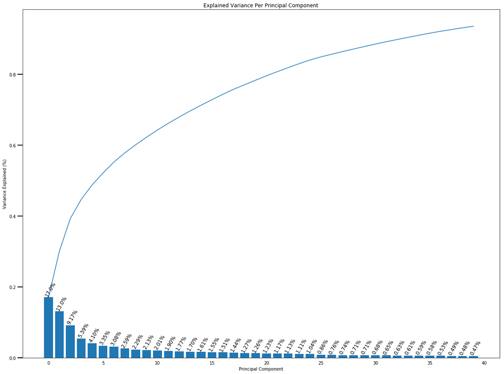

```python
scree_plot(azdias_pca)
```

```python
# Re-apply PCA to the data while selecting for number of components to retain.
pca = PCA(35)
azdias_pca = pca.fit(azdias_scaled)
```

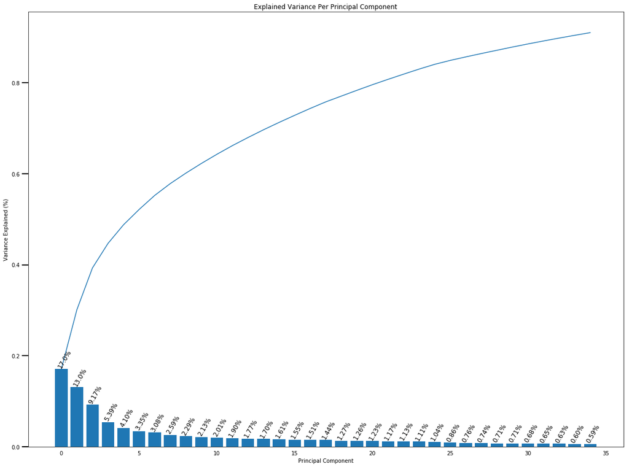

```python
scree_plot(azdias_pca)
```

### Discussion 2.2: Perform Dimensionality Reduction

35 principal components are being retained for the next step. Cumulatively, these account for about 90% of total variance.

### Step 2.3: Interpret Principal Components

Now that we have our transformed principal components, it's a nice idea to check out the weight of each variable on the first few components to see if they can be interpreted in some fashion.

As a reminder, each principal component is a unit vector that points in the direction of highest variance (after accounting for the variance captured by earlier principal components). The further a weight is from zero, the more the principal component is in the direction of the corresponding feature. If two features have large weights of the same sign (both positive or both negative), then increases in one tend expect to be associated with increases in the other. To contrast, features with different signs can be expected to show a negative correlation: increases in one variable should result in a decrease in the other.

- To investigate the features, you should map each weight to their corresponding feature name, then sort the features according to weight. The most interesting features for each principal component, then, will be those at the beginning and end of the sorted list. Use the data dictionary document to help you understand these most prominent features, their relationships, and what a positive or negative value on the principal component might indicate.
- You should investigate and interpret feature associations from the first three principal components in this substep. To help facilitate this, you should write a function that you can call at any time to print the sorted list of feature weights, for the *i*-th principal component. This might come in handy in the next step of the project, when you interpret the tendencies of the discovered clusters.

```python
# Map weights for the first principal component to corresponding feature names
# and then print the linked values, sorted by weight.
# HINT: Try defining a function here or in a new cell that you can reuse in the
# other cells.

def map_component(pca, comp):
    '''
    Maps a component to understand how the weighting of the components
    INPUT:
          pca - pca object created from PCA in sklearn
          comp - int - the component you want to see starting at 0
    OUTPUT
          None
    '''
    lst_comp = []
    feat_list = azdias_scaled.columns

    if comp <= len(pca.components_):

        for i in range(len(pca.components_[0])):
            lst_feat = [feat_list[i], pca.components_[comp][i]]
            lst_comp.append(lst_feat)

        lst_comp.sort(key=lambda x: x[1])

        for i in range(len(lst_comp)):
            print("{0:+.3f}".format(round(lst_comp[i][1],3)), '\t', lst_comp[i][0])
            #print(lst_comp[i][1], '\t', lst_comp[i][0])

    else:
        print('That is not the right input, please read the docstring before continuing.')
```

```python
map_component(azdias_pca,0)
```

```
-0.240 	 MOBI_REGIO
-0.224 	 KBA05_ANTG1
-0.222 	 PLZ8_ANTG1
-0.215 	 KBA05_GBZ
-0.214 	 FINANZ_MINIMALIST
-0.165 	 KONSUMNAEHE
-0.164 	 PLZ8_GBZ
-0.161 	 INNENSTADT
-0.151 	 LP_LEBENSPHASE_FEIN
-0.136 	 LP_LEBENSPHASE_GROB
-0.124 	 BALLRAUM
-0.122 	 CAMEO_INTL_2015_lifestage
-0.115 	 GEBAEUDETYP_RASTER
-0.113 	 PRAEGENDE_JUGENDJAHRE_movement
-0.113 	 GREEN_AVANTGARDE
-0.105 	 ALTERSKATEGORIE_GROB
-0.102 	 FINANZ_VORSORGER
-0.098 	 ANZ_PERSONEN
-0.077 	 KBA13_ANZAHL_PKW
-0.065 	 SEMIO_ERL
-0.064 	 SEMIO_LUST
-0.062 	 WOHNDAUER_2008
-0.059 	 ONLINE_AFFINITAET
-0.059 	 MIN_GEBAEUDEJAHR
-0.053 	 OST_WEST_KZ
-0.042 	 SEMIO_VERT
-0.010 	 RETOURTYP_BK_S
-0.005 	 ANZ_TITEL
-0.002 	 SOHO_KZ
+0.010 	 KBA05_ANTG2
+0.010 	 ANREDE_KZ
+0.012 	 SEMIO_KRIT
+0.024 	 SEMIO_DOM
+0.029 	 HEALTH_TYP
+0.032 	 VERS_TYP
+0.034 	 ANZ_HH_TITEL
+0.037 	 SEMIO_SOZ
+0.041 	 PLZ8_HHZ
+0.042 	 SEMIO_KAEM
+0.043 	 KKK
```

[output cut: 11 more lines]

```
+0.102 	 SEMIO_PFLICHT
+0.133 	 RELAT_AB
+0.133 	 FINANZ_SPARER
+0.134 	 KBA05_ANTG3
+0.135 	 ANZ_HAUSHALTE_AKTIV
+0.141 	 ARBEIT
+0.151 	 KBA05_ANTG4
+0.152 	 PLZ8_ANTG2
+0.166 	 FINANZ_HAUSBAUER
+0.191 	 EWDICHTE
+0.193 	 ORTSGR_KLS9
+0.206 	 CAMEO_INTL_2015_wealth
+0.206 	 HH_EINKOMMEN_SCORE
+0.215 	 PLZ8_ANTG4
+0.222 	 PLZ8_ANTG3
```

```python
# Map weights for the second principal component to corresponding feature names
# and then print the linked values, sorted by weight.
map_component(azdias_pca,1)
```

```
-0.262 	 SEMIO_REL
-0.247 	 PRAEGENDE_JUGENDJAHRE_decade
-0.243 	 FINANZ_SPARER
-0.235 	 SEMIO_PFLICHT
-0.235 	 SEMIO_TRADV
-0.231 	 FINANZ_UNAUFFAELLIGER
-0.224 	 SEMIO_KULT
-0.209 	 FINANZ_ANLEGER
-0.187 	 SEMIO_FAM
-0.176 	 SEMIO_RAT
-0.166 	 SEMIO_MAT
-0.164 	 ONLINE_AFFINITAET
-0.105 	 SEMIO_SOZ
-0.077 	 PLZ8_ANTG1
-0.075 	 KBA05_GBZ
-0.074 	 MOBI_REGIO
-0.067 	 SEMIO_VERT
-0.065 	 KBA05_ANTG1
-0.064 	 ANZ_PERSONEN
-0.063 	 INNENSTADT
-0.061 	 PLZ8_GBZ
-0.059 	 HEALTH_TYP
-0.058 	 KONSUMNAEHE
-0.052 	 BALLRAUM
-0.044 	 MIN_GEBAEUDEJAHR
-0.044 	 LP_LEBENSPHASE_GROB
-0.037 	 LP_LEBENSPHASE_FEIN
-0.036 	 GEBAEUDETYP_RASTER
-0.031 	 KBA13_ANZAHL_PKW
-0.022 	 OST_WEST_KZ
-0.010 	 GREEN_AVANTGARDE
-0.010 	 PRAEGENDE_JUGENDJAHRE_movement
-0.009 	 KBA05_ANTG2
-0.002 	 SOHO_KZ
+0.002 	 KKK
+0.007 	 ANZ_TITEL
+0.009 	 CAMEO_INTL_2015_lifestage
+0.011 	 PLZ8_HHZ
+0.017 	 REGIOTYP
+0.029 	 VERS_TYP
```

[output cut: 11 more lines]

```
+0.075 	 PLZ8_ANTG4
+0.077 	 ORTSGR_KLS9
+0.078 	 FINANZ_MINIMALIST
+0.079 	 EWDICHTE
+0.079 	 PLZ8_ANTG3
+0.090 	 ANREDE_KZ
+0.107 	 FINANZ_HAUSBAUER
+0.109 	 SEMIO_KAEM
+0.117 	 SEMIO_KRIT
+0.121 	 W_KEIT_KIND_HH
+0.164 	 RETOURTYP_BK_S
+0.185 	 SEMIO_LUST
+0.234 	 SEMIO_ERL
+0.238 	 FINANZ_VORSORGER
+0.265 	 ALTERSKATEGORIE_GROB
```

```python
# Map weights for the third principal component to corresponding feature names
# and then print the linked values, sorted by weight.
map_component(azdias_pca,2)
```

```
-0.369 	 ANREDE_KZ
-0.337 	 SEMIO_KAEM
-0.314 	 SEMIO_DOM
-0.274 	 SEMIO_KRIT
-0.217 	 SEMIO_RAT
-0.189 	 FINANZ_ANLEGER
-0.175 	 SEMIO_ERL
-0.110 	 PRAEGENDE_JUGENDJAHRE_decade
-0.106 	 FINANZ_SPARER
-0.099 	 FINANZ_UNAUFFAELLIGER
-0.079 	 SEMIO_PFLICHT
-0.079 	 SEMIO_TRADV
-0.054 	 ONLINE_AFFINITAET
-0.046 	 PLZ8_ANTG1
-0.044 	 FINANZ_HAUSBAUER
-0.043 	 INNENSTADT
-0.039 	 PLZ8_GBZ
-0.038 	 KONSUMNAEHE
-0.035 	 BALLRAUM
-0.030 	 GEBAEUDETYP_RASTER
-0.030 	 MOBI_REGIO
-0.027 	 KBA05_GBZ
-0.023 	 KBA13_ANZAHL_PKW
-0.023 	 KBA05_ANTG1
-0.020 	 HEALTH_TYP
-0.020 	 HH_EINKOMMEN_SCORE
-0.017 	 MIN_GEBAEUDEJAHR
-0.015 	 OST_WEST_KZ
-0.014 	 KKK
-0.011 	 KBA05_ANTG2
-0.010 	 ANZ_PERSONEN
-0.009 	 CAMEO_INTL_2015_lifestage
-0.005 	 LP_LEBENSPHASE_GROB
-0.004 	 REGIOTYP
-0.002 	 LP_LEBENSPHASE_FEIN
+0.000 	 SOHO_KZ
+0.004 	 PLZ8_HHZ
+0.006 	 VERS_TYP
+0.008 	 KBA05_ANTG3
+0.010 	 ANZ_TITEL
```

[output cut: 11 more lines]

```
+0.047 	 ORTSGR_KLS9
+0.049 	 GREEN_AVANTGARDE
+0.049 	 PRAEGENDE_JUGENDJAHRE_movement
+0.055 	 SEMIO_MAT
+0.064 	 SEMIO_LUST
+0.070 	 SEMIO_REL
+0.079 	 ALTERSKATEGORIE_GROB
+0.091 	 W_KEIT_KIND_HH
+0.100 	 FINANZ_VORSORGER
+0.109 	 RETOURTYP_BK_S
+0.157 	 FINANZ_MINIMALIST
+0.234 	 SEMIO_KULT
+0.250 	 SEMIO_FAM
+0.263 	 SEMIO_SOZ
+0.346 	 SEMIO_VERT
```

### Discussion 2.3: Interpret Principal Components

- -0.240 MOBI_REGIO
- -0.224 KBA05_ANTG1
- -0.222 PLZ8_ANTG1
- -0.215 KBA05_GBZ
- -0.214 FINANZ_MINIMALIST
- -0.002 SOHO_KZ Has a negligible role to play in determining the variance.
- +0.193 ORTSGR_KLS9
- +0.206 CAMEO_INTL_2015_wealth
- +0.206 HH_EINKOMMEN_SCORE
- +0.215 PLZ8_ANTG4
- +0.222 PLZ8_ANTG3

Based on the definition provided in the data dictionary, For Component #1: For the positive valued features, the record distribution is skewed towards lower values and for the negative valued features, the record distribution is skewed towards the higher values.

For ex. the positive valued features HH_EINKOMMEN_SCORE (household net income) and CAMEO_INTL_2015_wealth (wealth), which have a range between 1 to 6, 80% most of the records are mapped to values between 1 and 3. While for the negative valued feature FINANZ_MINIMALIST (minimalist/low financial interest) has a range from 3 to 5 and 90% of the records are mapped to the higher value. Distribution is from the customer dataset.

- -0.262 SEMIO_REL
- -0.247 PRAEGENDE_JUGENDJAHRE_decade
- -0.243 FINANZ_SPARER
- -0.235 SEMIO_PFLICHT
- -0.235 SEMIO_TRADV
- -0.002 SOHO_KZ Has a negligible role to play in determining the variance.
- +0.164 RETOURTYP_BK_S
- +0.185 SEMIO_LUST
- +0.234 SEMIO_ERL
- +0.238 FINANZ_VORSORGER
- +0.265 ALTERSKATEGORIE_GROB

For Component #2: For this component as it is orthogonal to Component #1, the record distribution is inverse. Positive valued features, the record distribution is skewed towards lower values and negative valued features, record distribution is skewed towards the higher values.

- -0.369 ANREDE_KZ
- -0.337 SEMIO_KAEM
- -0.314 SEMIO_DOM
- -0.274 SEMIO_KRIT
- -0.217 SEMIO_RAT
- +0.000 SOHO_KZ Has no role to play in determining the variance.
- +0.157 FINANZ_MINIMALIST
- +0.234 SEMIO_KULT
- +0.250 SEMIO_FAM
- +0.263 SEMIO_SOZ
- +0.346 SEMIO_VERT

## Step 3: Clustering

### Step 3.1: Apply Clustering to General Population

You've assessed and cleaned the demographics data, then scaled and transformed them. Now, it's time to see how the data clusters in the principal components space. In this substep, you will apply k-means clustering to the dataset and use the average within-cluster distances from each point to their assigned cluster's centroid to decide on a number of clusters to keep.

- Use sklearn's KMeans class to perform k-means clustering on the PCA-transformed data.
- Then, compute the average difference from each point to its assigned cluster's center. **Hint**: The KMeans object's `.score()` method might be useful here, but note that in sklearn, scores tend to be defined so that larger is better. Try applying it to a small, toy dataset, or use an internet search to help your understanding.
- Perform the above two steps for a number of different cluster counts. You can then see how the average distance decreases with an increasing number of clusters. However, each additional cluster provides a smaller net benefit. Use this fact to select a final number of clusters in which to group the data. **Warning**: because of the large size of the dataset, it can take a long time for the algorithm to resolve. The more clusters to fit, the longer the algorithm will take. You should test for cluster counts through at least 10 clusters to get the full picture, but you shouldn't need to test for a number of clusters above about 30.
- Once you've selected a final number of clusters to use, re-fit a KMeans instance to perform the clustering operation. Make sure that you also obtain the cluster assignments for the general demographics data, since you'll be using them in the final Step 3.3.

```python
azdias_pca = pca.fit_transform(azdias_scaled)
```

```python
# Over a number of different cluster counts...
scores = []
for k in range(3,20,1):

    # run k-means clustering on the data and...
    kmeans_k = KMeans(k) # instantiate model
    model_k = kmeans_k.fit(azdias_pca) #fit model to data
    labels_k = model_k.predict(azdias_pca) #predict labels using on dataset

    # compute the average within-cluster distances.
    score = np.abs(model_k.score(azdias_pca))
    scores.append(score) # Obtain a score related to the model fit
    print('k:', k, '\tScore:', score)
```

```
k: 3 	Score: 36786902.7403
k: 4 	Score: 34745710.0635
k: 5 	Score: 33347233.1369
k: 6 	Score: 32112418.3722
k: 7 	Score: 31015087.7218
k: 8 	Score: 30160982.5555
k: 9 	Score: 29576203.6749
k: 10 	Score: 29008100.2779
k: 11 	Score: 28415691.0273
k: 12 	Score: 27922895.4147
k: 13 	Score: 27490095.5709
k: 14 	Score: 27188715.5437
k: 15 	Score: 26954586.2873
k: 16 	Score: 26551390.9041
k: 17 	Score: 26280703.7196
k: 18 	Score: 26191990.8926
k: 19 	Score: 25592957.7088
```

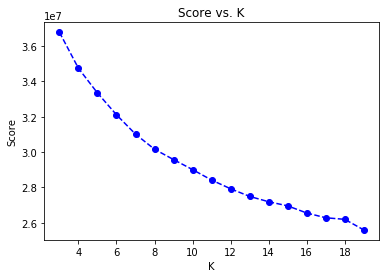

```python
# Investigate the change in within-cluster distance across number of clusters.
# HINT: Use matplotlib's plot function to visualize this relationship.
centers = list(range(3,20))

plt.plot(centers, scores, linestyle='--', marker='o', color='b');
plt.xlabel('K');
plt.ylabel('Score');
plt.title('Score vs. K');
```

```python
# Re-fit the k-means model with the selected number of clusters and obtain
# cluster predictions for the general population demographics data.

kmeans_k = KMeans(10) # instantiate model
model_k = kmeans_k.fit(azdias_pca) #fit model to data
labels_k = model_k.predict(azdias_pca) #predict labels using on dataset
```

```python
len(labels_k)
```

```
774743
```

```python
azdias_cleaned['cluster'] = labels_k
```

```python
azdias_cleaned.to_csv('Udacity_AZDIAS_Subset_31cluster.csv', sep=';', encoding='utf-8', index=False)
```

```python
# Load in the customers data.
azdias_cleaned = pd.read_csv('Udacity_AZDIAS_Subset_31cluster.csv', sep=';')
```

### Step 3.2: Apply All Steps to the Customer Data

Now that you have clusters and cluster centers for the general population, it's time to see how the customer data maps on to those clusters. Take care to not confuse this for re-fitting all of the models to the customer data. Instead, you're going to use the fits from the general population to clean, transform, and cluster the customer data. In the last step of the project, you will interpret how the general population fits apply to the customer data.

- Don't forget when loading in the customers data, that it is semicolon (`;`) delimited.
- Apply the same feature wrangling, selection, and engineering steps to the customer demographics using the `clean_data()` function you created earlier. (You can assume that the customer demographics data has similar meaning behind missing data patterns as the general demographics data.)
- Use the sklearn objects from the general demographics data, and apply their transformations to the customers data. That is, you should not be using a `.fit()` or `.fit_transform()` method to re-fit the old objects, nor should you be creating new sklearn objects! Carry the data through the feature scaling, PCA, and clustering steps, obtaining cluster assignments for all of the data in the customer demographics data.

```python
# Load in the customer demographics data.
cust = pd.read_csv('Udacity_CUSTOMERS_Subset.csv', sep=';')

# Load in the feature summary file.
feat_info = pd.read_csv('AZDIAS_Feature_Summary_12.csv', sep=';')
```

```python
# Apply preprocessing, feature transformation, and clustering from the general
# demographics onto the customer data, obtaining cluster predictions for the
# customer demographics data.
cust_cleaned = clean_data(cust)
```

```
Memory usage of dataframe is 124.29 MB
Memory usage after optimization is: 29.79 MB
Decreased by 76.0%
Shape Initial:  (191652, 85)
STEP #1: Identify missing or unknown data values and convert them to NaNs
Current Index: 0 Elapsed Time: 0.897207498550415
Current Index: 10000 Elapsed Time: 12.855358839035034
Current Index: 20000 Elapsed Time: 24.9473934173584
Current Index: 30000 Elapsed Time: 36.79660654067993
Current Index: 40000 Elapsed Time: 49.16539812088013
Current Index: 50000 Elapsed Time: 61.41899013519287
Current Index: 60000 Elapsed Time: 73.48567867279053
Current Index: 70000 Elapsed Time: 85.51136231422424
Current Index: 80000 Elapsed Time: 97.5326156616211
Current Index: 90000 Elapsed Time: 110.03311800956726
Current Index: 100000 Elapsed Time: 122.10823011398315
Current Index: 110000 Elapsed Time: 134.24646520614624
Current Index: 120000 Elapsed Time: 146.50782084465027
Current Index: 130000 Elapsed Time: 158.68766236305237
Current Index: 140000 Elapsed Time: 170.88841438293457
Current Index: 150000 Elapsed Time: 182.8142066001892
Current Index: 160000 Elapsed Time: 194.74849343299866
Current Index: 170000 Elapsed Time: 206.7620542049408
Current Index: 180000 Elapsed Time: 218.77752470970154
Current Index: 190000 Elapsed Time: 231.31770014762878
STEP #2: Remove columns with missing values
STEP #3: Remove rows with missing values
Missing Data Columns: 5 % of Records: 32.70
Missing Data Columns: 7 % of Records: 30.38
Missing Data Columns: 9 % of Records: 28.96
Missing Data Columns: 11 % of Records: 27.35
Missing Data Columns: 13 % of Records: 26.99
Missing Data Columns: 15 % of Records: 26.48
Missing Data Columns: 17 % of Records: 26.26
Missing Data Columns: 19 % of Records: 26.12
Missing Data Columns: 21 % of Records: 26.08
Missing Data Columns: 23 % of Records: 26.07
Missing Data Columns: 25 % of Records: 26.06
Missing Data Columns: 27 % of Records: 26.05
Missing Data Columns: 29 % of Records: 26.05
Records - Total          : 191652
Records - Below Threshold: 55493
Records - Above Threshold: 136159
STEP #4: Re-encode categorical variables
```

[output not shown]

```
Shape Final:  (136159, 66)
```

```python
cust_cleaned.to_csv('Udacity_CUSTOMERS_Subset_321.csv', sep=';', encoding='utf-8', index=False)
feat_info.to_csv('AZDIAS_Feature_Summary_321.csv', sep=';', encoding='utf-8', index=False)
```

```python
# Load in the customers data.
cust_cleaned = pd.read_csv('Udacity_CUSTOMERS_Subset_321.csv', sep=';')

# Load in the feature summary file.
feat_info = pd.read_csv('AZDIAS_Feature_Summary_321.csv', sep=';')
```

```python
prop_missing = cust_cleaned.isna().sum()/len(cust_cleaned) * 100
```

```python
print('Columns with missing values [Before Impute]:', prop_missing[prop_missing > 0].count())
```

```
Columns with missing values [Before Impute]: 31
```

```python
cust_imputed = imputer.transform(cust_cleaned)
```

```python
cust_imputed = pd.DataFrame(cust_imputed)
cust_imputed.columns = cust_cleaned.columns
```

```python
prop_missing_imputed = cust_imputed.isna().sum()/len(cust_imputed) * 100
```

```python
print('Columns with missing values [After Impute]:', prop_missing_imputed[prop_missing_imputed > 0].count())
```

```
Columns with missing values [After Impute]: 0
```

```python
# Apply feature scaling to the customer demographics data.
cust_scaled = ss.transform(cust_imputed)
```

```python
cust_scaled = pd.DataFrame(cust_scaled)
cust_scaled.columns = cust_imputed.columns
```

```python
cust_scaled.to_csv('Udacity_CUSTOMERS_Subset_322.csv', sep=';', encoding='utf-8', index=False)
feat_info.to_csv('AZDIAS_Feature_Summary_322.csv', sep=';', encoding='utf-8', index=False)
```

```python
# Load in the customers data.
cust_scaled = pd.read_csv('Udacity_CUSTOMERS_Subset_322.csv', sep=';')

# Load in the feature summary file.
feat_info = pd.read_csv('AZDIAS_Feature_Summary_322.csv', sep=';')
```

```python
cust_pca = pca.transform(cust_scaled)
```

```python
labels_cust = model_k.predict(cust_pca) #predict labels using on dataset
```

```python
cust_cleaned['cluster'] = labels_cust
```

```python
cust_cleaned.to_csv('Udacity_CUSTOMERS_Subset_323cluster.csv', sep=';', encoding='utf-8', index=False)
feat_info.to_csv('AZDIAS_Feature_Summary_323cluster.csv', sep=';', encoding='utf-8', index=False)
```

```python
# Load in the customers data.
cust_cleaned = pd.read_csv('Udacity_CUSTOMERS_Subset_323cluster.csv', sep=';')

# Load in the feature summary file.
feat_info = pd.read_csv('AZDIAS_Feature_Summary_323cluster.csv', sep=';')
```

### Step 3.3: Compare Customer Data to Demographics Data

At this point, you have clustered data based on demographics of the general population of Germany, and seen how the customer data for a mail-order sales company maps onto those demographic clusters. In this final substep, you will compare the two cluster distributions to see where the strongest customer base for the company is.

Consider the proportion of persons in each cluster for the general population, and the proportions for the customers. If we think the company's customer base to be universal, then the cluster assignment proportions should be fairly similar between the two. If there are only particular segments of the population that are interested in the company's products, then we should see a mismatch from one to the other. If there is a higher proportion of persons in a cluster for the customer data compared to the general population (e.g. 5% of persons are assigned to a cluster for the general population, but 15% of the customer data is closest to that cluster's centroid) then that suggests the people in that cluster to be a target audience for the company. On the other hand, the proportion of the data in a cluster being larger in the general population than the customer data (e.g. only 2% of customers closest to a population centroid that captures 6% of the data) suggests that group of persons to be outside of the target demographics.

Take a look at the following points in this step:

- Compute the proportion of data points in each cluster for the general population and the customer data. Visualizations will be useful here: both for the individual dataset proportions, but also to visualize the ratios in cluster representation between groups. Seaborn's [`countplot()`](https://seaborn.pydata.org/generated/seaborn.countplot.html) or [`barplot()`](https://seaborn.pydata.org/generated/seaborn.barplot.html) function could be handy.
  - Recall the analysis you performed in step 1.1.3 of the project, where you separated out certain data points from the dataset if they had more than a specified threshold of missing values. If you found that this group was qualitatively different from the main bulk of the data, you should treat this as an additional data cluster in this analysis. Make sure that you account for the number of data points in this subset, for both the general population and customer datasets, when making your computations!
- Which cluster or clusters are overrepresented in the customer dataset compared to the general population? Select at least one such cluster and infer what kind of people might be represented by that cluster. Use the principal component interpretations from step 2.3 or look at additional components to help you make this inference. Alternatively, you can use the `.inverse_transform()` method of the PCA and StandardScaler objects to transform centroids back to the original data space and interpret the retrieved values directly.
- Perform a similar investigation for the underrepresented clusters. Which cluster or clusters are underrepresented in the customer dataset compared to the general population, and what kinds of people are typified by these clusters?

```python
# Compare the proportion of data in each cluster for the customer data to the
# proportion of data in each cluster for the general population.

cluster_df = pd.DataFrame(columns=['cnt_general','cnt_customer'])
cluster_df['cnt_general'] = azdias_cleaned.groupby(['cluster']).size()
cluster_df['cnt_customer'] = cust_cleaned.groupby(['cluster']).size()
cluster_df['pct_general'] = round(cluster_df['cnt_general'] / cluster_df['cnt_general'].sum() * 100,2)
cluster_df['pct_customer'] = round(cluster_df['cnt_customer'] / cluster_df['cnt_customer'].sum() * 100,2)
cluster_df
```

| cluster | cnt_general | cnt_customer | pct_general | pct_customer |
| --- | --- | --- | --- | --- |
| 0 | 58837 | 2430 | 7.59 | 1.78 |
| 1 | 58676 | 46401 | 7.57 | 34.08 |
| 2 | 99714 | 13240 | 12.87 | 9.72 |
| 3 | 87459 | 26362 | 11.29 | 19.36 |
| 4 | 95820 | 14771 | 12.37 | 10.85 |
| 5 | 82252 | 2055 | 10.62 | 1.51 |
| 6 | 68135 | 1309 | 8.79 | 0.96 |
| 7 | 83082 | 11496 | 10.72 | 8.44 |
| 8 | 83684 | 1410 | 10.80 | 1.04 |
| 9 | 57084 | 16685 | 7.37 | 12.25 |

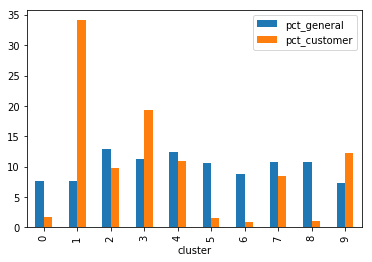

```python
cluster_df[['pct_general','pct_customer']].plot(kind='bar')
```

```python
# What kinds of people are part of a cluster that is overrepresented in the
# customer data compared to the general population?
cluster_or = 1
```

```python
cust_cleaned_pca_or = cust_cleaned.loc[:,['HH_EINKOMMEN_SCORE','CAMEO_INTL_2015_wealth','ORTSGR_KLS9','PLZ8_ANTG4','PLZ8_ANTG3',
                                          'MOBI_REGIO','PLZ8_ANTG1','KBA05_ANTG1','KBA05_GBZ','FINANZ_MINIMALIST',
                                          'RETOURTYP_BK_S','SEMIO_LUST','SEMIO_ERL','FINANZ_VORSORGER','ALTERSKATEGORIE_GROB',
                                          'SEMIO_REL','PRAEGENDE_JUGENDJAHRE_decade','FINANZ_SPARER','SEMIO_PFLICHT','SEMIO_TRADV',
                                          'ANREDE_KZ']]
```

```python
cust_subset_or = cust_cleaned[cust_cleaned['cluster'] == cluster_or]
```

```python
cust_subset_pca_or = cust_subset_or.loc[:,['HH_EINKOMMEN_SCORE','CAMEO_INTL_2015_wealth','ORTSGR_KLS9','PLZ8_ANTG4','PLZ8_ANTG3',
                                           'MOBI_REGIO','PLZ8_ANTG1','KBA05_ANTG1','KBA05_GBZ','FINANZ_MINIMALIST',
                                           'RETOURTYP_BK_S','SEMIO_LUST','SEMIO_ERL','FINANZ_VORSORGER','ALTERSKATEGORIE_GROB',
                                           'SEMIO_REL','PRAEGENDE_JUGENDJAHRE_decade','FINANZ_SPARER','SEMIO_PFLICHT','SEMIO_TRADV',
                                           'ANREDE_KZ']]
```

```python
cust_cleaned_pca_or.describe()
```

|  | HH_EINKOMMEN_SCORE | CAMEO_INTL_2015_wealth | ORTSGR_KLS9 | PLZ8_ANTG4 | PLZ8_ANTG3 | MOBI_REGIO | PLZ8_ANTG1 | KBA05_ANTG1 | KBA05_GBZ | FINANZ_MINIMALIST | RETOURTYP_BK_S | SEMIO_LUST | SEMIO_ERL | FINANZ_VORSORGER | ALTERSKATEGORIE_GROB | SEMIO_REL | PRAEGENDE_JUGENDJAHRE_decade | FINANZ_SPARER | SEMIO_PFLICHT | SEMIO_TRADV | ANREDE_KZ |
| --- | --- | --- | --- | --- | --- | --- | --- | --- | --- | --- | --- | --- | --- | --- | --- | --- | --- | --- | --- | --- | --- |
| count | 136159.000000 | 135939.000000 | 135649.000000 | 135378.000000 | 135378.000000 | 132321.000000 | 135378.000000 | 132321.000000 | 132319.000000 | 136159.000000 | 136159.000000 | 136159.000000 | 136159.000000 | 136159.000000 | 135947.000000 | 136159.000000 | 136159.000000 | 136159.000000 | 136159.000000 | 136159.000000 | 136159.000000 |
| mean | 3.254217 | 2.594789 | 5.111442 | 0.538655 | 1.386636 | 3.630127 | 2.539844 | 2.210201 | 3.631844 | 4.270441 | 3.917530 | 5.536233 | 4.874588 | 4.572250 | 3.494148 | 3.181920 | 2.896408 | 1.421360 | 3.012698 | 2.908063 | 1.329644 |
| std | 1.660481 | 1.405399 | 2.157868 | 0.636596 | 0.884741 | 1.281447 | 0.904871 | 1.382815 | 1.167613 | 1.015373 | 1.186612 | 1.622306 | 1.751532 | 0.837179 | 0.723697 | 1.454121 | 1.362768 | 0.823517 | 1.433472 | 1.388261 | 0.470086 |
| min | 1.000000 | 1.000000 | 1.000000 | 0.000000 | 0.000000 | 1.000000 | 0.000000 | 0.000000 | 1.000000 | 1.000000 | 1.000000 | 1.000000 | 1.000000 | 1.000000 | 1.000000 | 1.000000 | 1.000000 | 1.000000 | 1.000000 | 1.000000 | 1.000000 |
| 25% | 2.000000 | 1.000000 | 4.000000 | 0.000000 | 1.000000 | 3.000000 | 2.000000 | 1.000000 | 3.000000 | 4.000000 | 3.000000 | 4.000000 | 3.000000 | 4.000000 | 3.000000 | 2.000000 | 2.000000 | 1.000000 | 2.000000 | 2.000000 | 1.000000 |
| 50% | 3.000000 | 2.000000 | 5.000000 | 0.000000 | 1.000000 | 4.000000 | 3.000000 | 2.000000 | 4.000000 | 5.000000 | 4.000000 | 6.000000 | 4.000000 | 5.000000 | 4.000000 | 3.000000 | 3.000000 | 1.000000 | 3.000000 | 3.000000 | 1.000000 |
| 75% | 5.000000 | 4.000000 | 7.000000 | 1.000000 | 2.000000 | 5.000000 | 3.000000 | 3.000000 | 5.000000 | 5.000000 | 5.000000 | 7.000000 | 7.000000 | 5.000000 | 4.000000 | 4.000000 | 4.000000 | 2.000000 | 4.000000 | 4.000000 | 2.000000 |
| max | 6.000000 | 5.000000 | 9.000000 | 2.000000 | 3.000000 | 6.000000 | 4.000000 | 4.000000 | 5.000000 | 5.000000 | 5.000000 | 7.000000 | 7.000000 | 5.000000 | 4.000000 | 7.000000 | 6.000000 | 5.000000 | 7.000000 | 7.000000 | 2.000000 |

```python
cust_subset_pca_or.describe()
```

|  | HH_EINKOMMEN_SCORE | CAMEO_INTL_2015_wealth | ORTSGR_KLS9 | PLZ8_ANTG4 | PLZ8_ANTG3 | MOBI_REGIO | PLZ8_ANTG1 | KBA05_ANTG1 | KBA05_GBZ | FINANZ_MINIMALIST | RETOURTYP_BK_S | SEMIO_LUST | SEMIO_ERL | FINANZ_VORSORGER | ALTERSKATEGORIE_GROB | SEMIO_REL | PRAEGENDE_JUGENDJAHRE_decade | FINANZ_SPARER | SEMIO_PFLICHT | SEMIO_TRADV | ANREDE_KZ |
| --- | --- | --- | --- | --- | --- | --- | --- | --- | --- | --- | --- | --- | --- | --- | --- | --- | --- | --- | --- | --- | --- |
| count | 46401.000000 | 46340.000000 | 46297.000000 | 46191.000000 | 46191.000000 | 45766.000000 | 46191.000000 | 45766.000000 | 45766.000000 | 46401.000000 | 46401.000000 | 46401.000000 | 46401.000000 | 46401.000000 | 46338.000000 | 46401.000000 | 46401.000000 | 46401.000000 | 46401.000000 | 46401.000000 | 46401.000000 |
| mean | 2.112131 | 2.030039 | 5.399486 | 0.430084 | 1.268580 | 4.181357 | 2.768180 | 2.858803 | 4.053489 | 4.877524 | 4.110450 | 5.802009 | 3.989483 | 4.706536 | 3.608593 | 3.621129 | 2.688433 | 1.256331 | 2.822288 | 3.012995 | 1.000022 |
| std | 1.195065 | 1.210992 | 1.836279 | 0.522620 | 0.728387 | 0.813154 | 0.781687 | 1.026233 | 0.779490 | 0.384925 | 1.091335 | 1.476760 | 1.426813 | 0.662820 | 0.575561 | 1.167589 | 1.254996 | 0.580599 | 1.223430 | 1.347437 | 0.004642 |
| min | 1.000000 | 1.000000 | 1.000000 | 0.000000 | 0.000000 | 1.000000 | 0.000000 | 0.000000 | 1.000000 | 1.000000 | 1.000000 | 1.000000 | 1.000000 | 1.000000 | 1.000000 | 2.000000 | 1.000000 | 1.000000 | 1.000000 | 1.000000 | 1.000000 |
| 25% | 1.000000 | 1.000000 | 4.000000 | 0.000000 | 1.000000 | 4.000000 | 2.000000 | 2.000000 | 3.000000 | 5.000000 | 3.000000 | 5.000000 | 3.000000 | 5.000000 | 3.000000 | 3.000000 | 2.000000 | 1.000000 | 2.000000 | 1.000000 | 1.000000 |
| 50% | 2.000000 | 2.000000 | 5.000000 | 0.000000 | 1.000000 | 4.000000 | 3.000000 | 3.000000 | 4.000000 | 5.000000 | 5.000000 | 6.000000 | 4.000000 | 5.000000 | 4.000000 | 4.000000 | 2.000000 | 1.000000 | 3.000000 | 4.000000 | 1.000000 |
| 75% | 3.000000 | 3.000000 | 7.000000 | 1.000000 | 2.000000 | 5.000000 | 3.000000 | 4.000000 | 5.000000 | 5.000000 | 5.000000 | 7.000000 | 4.000000 | 5.000000 | 4.000000 | 4.000000 | 4.000000 | 1.000000 | 4.000000 | 4.000000 | 1.000000 |
| max | 6.000000 | 5.000000 | 9.000000 | 2.000000 | 3.000000 | 6.000000 | 4.000000 | 4.000000 | 5.000000 | 5.000000 | 5.000000 | 7.000000 | 7.000000 | 5.000000 | 4.000000 | 7.000000 | 6.000000 | 5.000000 | 7.000000 | 5.000000 | 2.000000 |

```python
for col in cust_subset_pca_or.columns:
    print('Column:', col, 'Unique Value:', cust_subset_pca_or.groupby([col]).size())
```

```
Column: HH_EINKOMMEN_SCORE Unique Value: HH_EINKOMMEN_SCORE
1.0    19467
2.0    11646
3.0     7832
4.0     5579
5.0     1828
6.0       49
dtype: int64
Column: CAMEO_INTL_2015_wealth Unique Value: CAMEO_INTL_2015_wealth
1.0    21031
2.0    13163
3.0     3864
4.0     6287
5.0     1995
dtype: int64
Column: ORTSGR_KLS9 Unique Value: ORTSGR_KLS9
1.0      462
2.0     2181
3.0     3391
4.0     9230
5.0    11273
6.0     5952
7.0     7401
8.0     3484
9.0     2923
dtype: int64
Column: PLZ8_ANTG4 Unique Value: PLZ8_ANTG4
0.0    26972
1.0    18572
2.0      647
dtype: int64
Column: PLZ8_ANTG3 Unique Value: PLZ8_ANTG3
0.0     6707
1.0    21380
2.0    17095
3.0     1009
dtype: int64
Column: MOBI_REGIO Unique Value: MOBI_REGIO
1.0       82
2.0      707
```

[output cut: 97 more lines]

```
5.0     1937
6.0      309
7.0      289
dtype: int64
Column: SEMIO_TRADV Unique Value: SEMIO_TRADV
1.0    11608
2.0     5991
3.0        1
4.0    27792
5.0     1009
dtype: int64
Column: ANREDE_KZ Unique Value: ANREDE_KZ
1.0    46400
2.0        1
dtype: int64
```

```python
# What kinds of people are part of a cluster that is underrepresented in the
# customer data compared to the general population?
cluster_ur = 8
```

```python
cust_cleaned_pca_ur = cust_cleaned.loc[:,['HH_EINKOMMEN_SCORE','CAMEO_INTL_2015_wealth','ORTSGR_KLS9','PLZ8_ANTG4','PLZ8_ANTG3',
                                          'MOBI_REGIO','PLZ8_ANTG1','KBA05_ANTG1','KBA05_GBZ','FINANZ_MINIMALIST',
                                          'RETOURTYP_BK_S','SEMIO_LUST','SEMIO_ERL','FINANZ_VORSORGER','ALTERSKATEGORIE_GROB',
                                          'SEMIO_REL','PRAEGENDE_JUGENDJAHRE_decade','FINANZ_SPARER','SEMIO_PFLICHT','SEMIO_TRADV',
                                          'ANREDE_KZ']]
```

```python
cust_subset_ur = cust_cleaned[cust_cleaned['cluster'] == cluster_ur]
```

```python
cust_subset_pca_ur = cust_subset_ur.loc[:,['HH_EINKOMMEN_SCORE','CAMEO_INTL_2015_wealth','ORTSGR_KLS9','PLZ8_ANTG4','PLZ8_ANTG3',
                                           'MOBI_REGIO','PLZ8_ANTG1','KBA05_ANTG1','KBA05_GBZ','FINANZ_MINIMALIST',
                                           'RETOURTYP_BK_S','SEMIO_LUST','SEMIO_ERL','FINANZ_VORSORGER','ALTERSKATEGORIE_GROB',
                                           'SEMIO_REL','PRAEGENDE_JUGENDJAHRE_decade','FINANZ_SPARER','SEMIO_PFLICHT','SEMIO_TRADV',
                                           'ANREDE_KZ']]
```

```python
cust_cleaned_pca_ur.describe()
```

|  | HH_EINKOMMEN_SCORE | CAMEO_INTL_2015_wealth | ORTSGR_KLS9 | PLZ8_ANTG4 | PLZ8_ANTG3 | MOBI_REGIO | PLZ8_ANTG1 | KBA05_ANTG1 | KBA05_GBZ | FINANZ_MINIMALIST | RETOURTYP_BK_S | SEMIO_LUST | SEMIO_ERL | FINANZ_VORSORGER | ALTERSKATEGORIE_GROB | SEMIO_REL | PRAEGENDE_JUGENDJAHRE_decade | FINANZ_SPARER | SEMIO_PFLICHT | SEMIO_TRADV | ANREDE_KZ |
| --- | --- | --- | --- | --- | --- | --- | --- | --- | --- | --- | --- | --- | --- | --- | --- | --- | --- | --- | --- | --- | --- |
| count | 136159.000000 | 135939.000000 | 135649.000000 | 135378.000000 | 135378.000000 | 132321.000000 | 135378.000000 | 132321.000000 | 132319.000000 | 136159.000000 | 136159.000000 | 136159.000000 | 136159.000000 | 136159.000000 | 135947.000000 | 136159.000000 | 136159.000000 | 136159.000000 | 136159.000000 | 136159.000000 | 136159.000000 |
| mean | 3.254217 | 2.594789 | 5.111442 | 0.538655 | 1.386636 | 3.630127 | 2.539844 | 2.210201 | 3.631844 | 4.270441 | 3.917530 | 5.536233 | 4.874588 | 4.572250 | 3.494148 | 3.181920 | 2.896408 | 1.421360 | 3.012698 | 2.908063 | 1.329644 |
| std | 1.660481 | 1.405399 | 2.157868 | 0.636596 | 0.884741 | 1.281447 | 0.904871 | 1.382815 | 1.167613 | 1.015373 | 1.186612 | 1.622306 | 1.751532 | 0.837179 | 0.723697 | 1.454121 | 1.362768 | 0.823517 | 1.433472 | 1.388261 | 0.470086 |
| min | 1.000000 | 1.000000 | 1.000000 | 0.000000 | 0.000000 | 1.000000 | 0.000000 | 0.000000 | 1.000000 | 1.000000 | 1.000000 | 1.000000 | 1.000000 | 1.000000 | 1.000000 | 1.000000 | 1.000000 | 1.000000 | 1.000000 | 1.000000 | 1.000000 |
| 25% | 2.000000 | 1.000000 | 4.000000 | 0.000000 | 1.000000 | 3.000000 | 2.000000 | 1.000000 | 3.000000 | 4.000000 | 3.000000 | 4.000000 | 3.000000 | 4.000000 | 3.000000 | 2.000000 | 2.000000 | 1.000000 | 2.000000 | 2.000000 | 1.000000 |
| 50% | 3.000000 | 2.000000 | 5.000000 | 0.000000 | 1.000000 | 4.000000 | 3.000000 | 2.000000 | 4.000000 | 5.000000 | 4.000000 | 6.000000 | 4.000000 | 5.000000 | 4.000000 | 3.000000 | 3.000000 | 1.000000 | 3.000000 | 3.000000 | 1.000000 |
| 75% | 5.000000 | 4.000000 | 7.000000 | 1.000000 | 2.000000 | 5.000000 | 3.000000 | 3.000000 | 5.000000 | 5.000000 | 5.000000 | 7.000000 | 7.000000 | 5.000000 | 4.000000 | 4.000000 | 4.000000 | 2.000000 | 4.000000 | 4.000000 | 2.000000 |
| max | 6.000000 | 5.000000 | 9.000000 | 2.000000 | 3.000000 | 6.000000 | 4.000000 | 4.000000 | 5.000000 | 5.000000 | 5.000000 | 7.000000 | 7.000000 | 5.000000 | 4.000000 | 7.000000 | 6.000000 | 5.000000 | 7.000000 | 7.000000 | 2.000000 |

```python
cust_subset_pca_ur.describe()
```

|  | HH_EINKOMMEN_SCORE | CAMEO_INTL_2015_wealth | ORTSGR_KLS9 | PLZ8_ANTG4 | PLZ8_ANTG3 | MOBI_REGIO | PLZ8_ANTG1 | KBA05_ANTG1 | KBA05_GBZ | FINANZ_MINIMALIST | RETOURTYP_BK_S | SEMIO_LUST | SEMIO_ERL | FINANZ_VORSORGER | ALTERSKATEGORIE_GROB | SEMIO_REL | PRAEGENDE_JUGENDJAHRE_decade | FINANZ_SPARER | SEMIO_PFLICHT | SEMIO_TRADV | ANREDE_KZ |
| --- | --- | --- | --- | --- | --- | --- | --- | --- | --- | --- | --- | --- | --- | --- | --- | --- | --- | --- | --- | --- | --- |
| count | 1410.000000 | 1406.000000 | 1406.000000 | 1397.000000 | 1397.000000 | 1391.000000 | 1397.000000 | 1391.000000 | 1391.000000 | 1410.000000 | 1410.000000 | 1410.000000 | 1410.000000 | 1410.000000 | 1402.000000 | 1410.000000 | 1410.000000 | 1410.000000 | 1410.000000 | 1410.000000 | 1410.000000 |
| mean | 5.235461 | 4.182077 | 7.295164 | 1.378669 | 2.510379 | 1.817398 | 1.387258 | 0.401150 | 2.145938 | 1.668794 | 3.110638 | 3.261702 | 4.497163 | 2.892199 | 1.748930 | 5.268794 | 4.956028 | 3.375887 | 5.953191 | 5.534043 | 1.991489 |
| std | 0.850761 | 0.925475 | 1.573017 | 0.611895 | 0.601514 | 0.867320 | 0.583619 | 0.661456 | 1.026054 | 0.788638 | 1.363818 | 1.917095 | 1.612251 | 1.320691 | 0.719675 | 1.545415 | 1.363437 | 1.410892 | 1.156004 | 1.772526 | 0.091892 |
| min | 1.000000 | 1.000000 | 3.000000 | 0.000000 | 0.000000 | 1.000000 | 0.000000 | 0.000000 | 1.000000 | 1.000000 | 1.000000 | 1.000000 | 2.000000 | 1.000000 | 1.000000 | 1.000000 | 1.000000 | 1.000000 | 1.000000 | 1.000000 | 1.000000 |
| 25% | 5.000000 | 4.000000 | 6.000000 | 1.000000 | 2.000000 | 1.000000 | 1.000000 | 0.000000 | 1.000000 | 1.000000 | 2.000000 | 2.000000 | 4.000000 | 2.000000 | 1.000000 | 4.000000 | 4.000000 | 2.000000 | 6.000000 | 6.000000 | 2.000000 |
| 50% | 5.000000 | 4.000000 | 7.000000 | 1.000000 | 3.000000 | 2.000000 | 1.000000 | 0.000000 | 2.000000 | 1.000000 | 3.000000 | 3.000000 | 5.000000 | 3.000000 | 2.000000 | 5.000000 | 5.000000 | 4.000000 | 6.000000 | 6.000000 | 2.000000 |
| 75% | 6.000000 | 5.000000 | 9.000000 | 2.000000 | 3.000000 | 2.000000 | 2.000000 | 1.000000 | 3.000000 | 2.000000 | 5.000000 | 5.000000 | 5.000000 | 4.000000 | 2.000000 | 7.000000 | 6.000000 | 5.000000 | 7.000000 | 7.000000 | 2.000000 |
| max | 6.000000 | 5.000000 | 9.000000 | 2.000000 | 3.000000 | 6.000000 | 4.000000 | 4.000000 | 5.000000 | 5.000000 | 5.000000 | 7.000000 | 7.000000 | 5.000000 | 4.000000 | 7.000000 | 6.000000 | 5.000000 | 7.000000 | 7.000000 | 2.000000 |

```python
for col in cust_subset_pca_ur.columns:
    print('Column:', col, 'Unique Value:', cust_subset_pca_ur.groupby([col]).size())
```

```
Column: HH_EINKOMMEN_SCORE Unique Value: HH_EINKOMMEN_SCORE
1.0      1
2.0      7
3.0     38
4.0    217
5.0    497
6.0    650
dtype: int64
Column: CAMEO_INTL_2015_wealth Unique Value: CAMEO_INTL_2015_wealth
1.0     26
2.0     63
3.0    152
4.0    553
5.0    612
dtype: int64
Column: ORTSGR_KLS9 Unique Value: ORTSGR_KLS9
3.0     21
4.0     54
5.0    170
6.0    124
7.0    336
8.0    277
9.0    424
dtype: int64
Column: PLZ8_ANTG4 Unique Value: PLZ8_ANTG4
0.0     97
1.0    674
2.0    626
dtype: int64
Column: PLZ8_ANTG3 Unique Value: PLZ8_ANTG3
0.0      8
1.0     54
2.0    552
3.0    783
dtype: int64
Column: MOBI_REGIO Unique Value: MOBI_REGIO
1.0    621
2.0    447
3.0    286
4.0     31
```

[output cut: 96 more lines]

```
6.0    558
7.0    517
dtype: int64
Column: SEMIO_TRADV Unique Value: SEMIO_TRADV
1.0      3
2.0    154
3.0    176
4.0     18
6.0    521
7.0    538
dtype: int64
Column: ANREDE_KZ Unique Value: ANREDE_KZ
1.0      12
2.0    1398
dtype: int64
```

### Discussion 3.3: Compare Customer Data to Demographics Data

Population segments relatively popular with the mail-order company are those who are:

1. Wealthy and High Income households (HH_EINKOMMEN_SCORE values between 1 and 3 and CAMEO_INTL_2015_wealth values between 1 and 2)
2. Movement pattern is low/very low (MOBI_REGIO mostly 4 or 5)
3. Minimal Returned (RETOURTYP_BK_S is 5)
4. Personality topology is Event-oriented, religious, traditional, dutiful and hardly sensual-minded
5. Financial Topology is very high interest in finance (FINANZ_MINIMALIST), very low preparedensss (FINANZ_VORSORGER), mostly money savers (FINANZ_SPARER)
6. Mostly male with estimated age is > 60 and dominating event in person's life was in the 40s/50s

> Congratulations on making it this far in the project! Before you finish, make sure to check through the entire notebook from top to bottom to make sure that your analysis follows a logical flow and all of your findings are documented in **Discussion** cells. Once you've checked over all of your work, you should export the notebook as an HTML document to submit for evaluation. You can do this from the menu, navigating to **File -> Download as -> HTML (.html)**. You will submit both that document and this notebook for your project submission.